# Analyse Économétrique Spatiale du Vote Emmanuel Macron à l’Élection Présidentielle de 2022

Structure Spatiale, Autocorrélation (Moran, LISA) et Modélisation (SDM, SAR, SEM, SLX, SDEM, SAC)

# 1 Introduction générale et contexte de l’étude

## 1.1 Contexte politique et géographique de l’élection présidentielle de 2022

L’élection présidentielle française des 10 et 24 avril 2022 s’est inscrite dans un contexte institutionnel, économique et géopolitique inédit. Marquée par la sortie progressive de la crise sanitaire de la Covid-19, la flambée des cours de l’énergie consécutive au déclenchement de la guerre en Ukraine quelques semaines plus tôt, et une crise profonde du pouvoir d’achat, cette élection a confirmé la tripartition du paysage politique français engagée dès 2017 :

1. Un **pôle central libéral-progressiste**, incarné par le président sortant Emmanuel Macron (La République en Marche / Renaissance), soutenu par les classes moyennes supérieures urbaines, les cadres, et une large fraction des électeurs retraités ;
2. Un **pôle nationaliste et populiste de droite**, mené par Marine Le Pen (Rassemblement National), fortement ancré dans les territoires ouvriers, périurbains et ruraux fragilisés par les mutations industrielles ;
3. Un **pôle de gauche radicale et écologiste**, porté par Jean-Luc Mélenchon (La France Insoumise), obtenant des scores élevés dans les cœurs métropolitains denses et les banlieues populaires diversifiées.

Ces écarts géographiques majeurs posent avec acuité la question de la structuration spatiale du vote. L’observation des cartes électorales révèle d’emblée une forte contiguïté des comportements électoraux : les zones de force d’Emmanuel Macron ne sont pas disséminées de manière aléatoire sur le territoire national, mais forment des grappes territoriales (*clusters*) remarquablement homogènes.

## 1.2 Problématique centrale

Face à ce constat, le présent projet répond à la problématique suivante :

> **Quels sont les déterminants démographiques, économiques et territoriaux du vote pour Emmanuel Macron au premier tour de l’élection présidentielle de 2022, et dans quelle mesure ce vote est-il structuré par des effets d’interdépendance et de débordement spatial entre départements ?**

Cette problématique se décompose en plusieurs sous-questions de recherche : * Les caractéristiques socio-économiques locales (richesse, pauvreté, chômage, niveau de qualification, structure par âge) suffisent-elles à expliquer les écarts de score observés ? * Existe-t-il une autocorrélation spatiale significative dans le vote et dans les variables explicatives ? * Les départements voisins s’influencent-ils mutuellement (débordement endogène du comportement électoral, effet d’imitation ou de climat politique régional) ? * Les caractéristiques des voisins ont-elles un effet propre sur le vote local (externalités spatiales exogènes) ? * Quel modèle d’économétrie spatiale (SDM, SAR, SEM, SLX, SDEM ou SAC) offre la meilleure représentation des mécanismes territoriaux sous-jacents ?

## 1.3 Hypothèses théoriques

S’appuyant sur les travaux contemporains de sociologie électorale et d’économie géographique (Guilluy, 2014 ; Fourquet, 2019 ; Algan et al., 2018), nous formulons cinq hypothèses théoriques fondamentales :

- **Hypothèse 1 (Capital humain et statut professionnel - Le « bloc bourgeois ») :** Le vote Macron est positivement associé à la proportion de cadres et de professions intellectuelles supérieures, symboles des catégories intégrées à l’économie mondialisée de la connaissance.
- **Hypothèse 2 (Précarité, pauvreté et sentiment de déclassement) :** Les territoires les plus durement frappés par la pauvreté monétaire et la précarité sanctionnent le président sortant, privilégiant les votes contestataires.
- **Hypothèse 3 (Démographie et vieillissement) :** L’électorat d’Emmanuel Macron bénéficie traditionnellement d’une surreprésentation marquée chez les électeurs âgés et retraités, attachés à la stabilité institutionnelle et aux garanties de pouvoir d’achat des pensions. Nous anticipons une corrélation positive avec l’indice de vieillissement.
- **Hypothèse 4 (Densité et structuration urbaine/rurale) :** Les zones à forte densité bénéficient de services publics, d’aménités et d’une dynamique économique favorable à la majorité présidentielle, tandis que les zones rurales et périurbaines isolées (« France périphérique ») lui sont plus hostiles.
- **Hypothèse 5 (Interdépendance et débordements spatiaux) :** Le vote pour un candidat ne s’arrête pas aux frontières administratives départementales. Les dynamiques de bassin d’emploi, les médias régionaux et les réseaux d’influence créent une autocorrélation spatiale positive ($\rho > 0$), justifiant l’abandon des MCO classiques au profit de modèles spatiaux autoregressifs.

# 2 Cadre méthodologique et sources de données

## 2.1 Champ d’analyse et unité spatiale

L’unité statistique retenue est le **département**. Le champ d’analyse est circonscrit à la **France métropolitaine, Corse comprise** ($n = 96$ départements).

Les départements et territoires d’outre-mer (DROM-COM) ainsi que les votes des Français de l’étranger sont exclus du champ d’étude pour plusieurs raisons méthodologiques impératives : * Leur isolement géographique absolu brise la continuité territoriale nécessaire à la définition d’un graphe de contiguïté spatiale standard ; * Leurs contextes politiques et socio-économiques spécifiques (chômage structurellement très supérieur, structures démographiques divergentes) introduiraient des points aberrants extrêmes susceptibles de biaiser lourdement les estimateurs spatiaux.

La Corse (Corse-du-Sud `2A` et Haute-Corse `2B`), bien qu’insulaire, est conservée dans l’échantillon. En contiguïté pure, les deux départements corses forment un sous-graphe connexe isolé du continent ; nous explorerons comment les matrices basées sur la distance permettent de raccorder l’ensemble du territoire national.

## 2.2 Sources de données

L’étude mobilise deux sources officielles de données :

1. **Données électorales :** Résultats officiels du premier tour de l’élection présidentielle de 2022, issus du Ministère de l’Intérieur et compilés dans le fichier `Data/france-politique.fr-presidentielle-2022.xlsx` (feuille « Premier tour »).
2. **Données socio-économiques et démographiques :** Données Insee issues de la base de statistiques locales, compilées dans `Data/donnees_sociaux_economiques_2023.csv`.

## 2.3 Définition et transformation des indicateurs

La variable dépendante est notée **`Macron_EXP`** : part des suffrages exprimés obtenue par Emmanuel Macron au premier tour de l’élection présidentielle de 2022 (en pourcentage).

Les variables explicatives initialement fournies dans le fichier socio-économique couvrent 14 indicateurs. Pour éviter les pièges méthodologiques classiques en économétrie spatiale, plusieurs transformations sont appliquées :

```r
# 1. Lecture des résultats électoraux
election_brut <- read_excel("Data/france-politique.fr-presidentielle-2022.xlsx", sheet = "Premier tour")
election <- election_brut %>%
  transmute(code_dep = trimws(as.character(DEP_CODE)),
            code_dep = ifelse(grepl("^[0-9]+$", code_dep), sprintf("%02d", as.integer(code_dep)), code_dep),
            Macron_VOIX = as.numeric(Macron_VOIX),
            Macron_EXP = as.numeric(Macron_EXP))

# 2. Lecture des indicateurs socio-économiques Insee
eco_brut <- read.csv("Data/donnees_sociaux_economiques_2023.csv", sep = ";", skip = 2,
                     fileEncoding = "UTF-8-BOM", check.names = FALSE,
                     na.strings = c("", "NA", "nd", "s"), colClasses = "character")

eco <- eco_brut %>%
  rename(code_dep = `Code`,
         departement = `Libellé`,
         population = `Population municipale 2023`,
         pauvrete = `Taux de pauvreté 2023`,
         densite = `Densité de population (historique depuis 1876) 2023`,
         part_res_principales = `Part des rés. principales dans le total des logements 2023`,
         niveau_vie = `Médiane du niveau de vie 2023`,
         vieillissement = `Indice de vieillissement 2023`,
         logements_vacants = `Part des logements vacants dans le total des logements 2023`,
         suroccupation = `Part des résidences principales en suroccupation accentuée 2023`,
         cadres = `Pop 15 ans ou plus Cadres, Prof. intel. sup. 2023`,
         activite = `Taux d'activité de 15 à 64 ans 2023`,
         proprietaires = `Part des propriétaires dans les rés. principales 2023`,
         natalite = `Taux de natalité 2025`,
         moins_25 = `Part des pers. âgées de moins de 25 ans 2023`,
         inscrits_2022 = `Électeurs inscrits sur liste principale 2022`) %>%
  mutate(code_dep = trimws(code_dep))

vars_num <- c("population", "pauvrete", "densite", "part_res_principales", "niveau_vie",
              "vieillissement", "logements_vacants", "suroccupation", "cadres",
              "activite", "proprietaires", "natalite", "moins_25", "inscrits_2022")

eco[vars_num] <- lapply(eco[vars_num], function(x) {
  as.numeric(gsub(",", ".", gsub(" ", "", x, fixed = TRUE), fixed = TRUE))
})

# 3. Restriction métropolitaine (96 départements)
codes_metro <- c(sprintf("%02d", 1:19), "2A", "2B", sprintf("%02d", 21:95))
donnees <- inner_join(filter(eco, code_dep %in% codes_metro), election, by = "code_dep") %>%
  filter(!is.na(Macron_EXP)) %>%
  arrange(code_dep)

# 4. Fond de carte sf (package maps)
norm_nom <- function(x) gsub("[^a-z0-9]", "", tolower(iconv(x, to = "ASCII//TRANSLIT")))

carte <- st_as_sf(maps::map("france", plot = FALSE, fill = TRUE)) %>%
  mutate(cle = norm_nom(ID)) %>%
  left_join(mutate(donnees, cle = norm_nom(departement)), by = "cle") %>%
  st_transform(2154) %>%
  arrange(code_dep) %>%
  mutate(cadres_pct = cadres / population * 100,
         ldens = log(densite),
         nv_k = niveau_vie / 1000)

stopifnot(nrow(carte) == 96, !anyNA(carte$Macron_EXP))
rownames(carte) <- carte$code_dep
centroides <- st_centroid(st_geometry(carte))
```

La fusion aboutit à un échantillon parfait de **96 départements métropolitains**, sans aucune donnée manquante.

## 2.4 Précautions méthodologiques et limites épistémologiques

Avant de débuter l’analyse, trois limites méthodologiques majeures doivent être explicitées :

1. **L’erreur écologique (Robinson, 1950) :** Les résultats obtenus au niveau agrégé des départements mesurent des associations territoriales et ne peuvent pas être directement transposés à des comportements électoraux individuels. Constater qu’un département ayant un fort taux de pauvreté vote moins pour Macron ne prouve pas que chaque électeur pauvre rejette Macron.
2. **Le problème des unités spatiales modifiables (MAUP - Openshaw, 1984) :** Le découpage départemental est le produit de l’histoire administrative française et regroupe des bassins de vie hétérogènes. Une agrégation à l’échelle des communes ou des zones d’emploi pourrait modifier légèrement l’amplitude des coefficients.
3. **Le décalage temporel :** La majorité des indicateurs socio-économiques sont millésimés 2023 (et 2025 pour la natalité), tandis que le vote date d’avril 2022. Bien que les structures démographiques et économiques départementales évoluent très lentement, cette postériorité interdit formellement d’affirmer une causalité stricte au sens temporel.

# 3 Analyse descriptive univariée et distribution spatiale

## 3.1 Statistiques descriptives univariées

Le tableau ci-dessous synthétise la distribution de l’ensemble des variables de l’étude à travers les 96 départements métropolitains :

```r
vars_desc <- c("Macron_EXP", "pauvrete", "densite", "ldens", "niveau_vie", "nv_k",
               "vieillissement", "cadres_pct", "activite", "proprietaires",
               "part_res_principales", "logements_vacants", "suroccupation",
               "natalite", "moins_25")

labels_desc <- c(Macron_EXP = "Score Macron (% exprimés)",
                 pauvrete = "Taux de pauvreté (%)",
                 densite = "Densité brute (hab/km²)",
                 ldens = "Log(Densité)",
                 niveau_vie = "Niveau de vie médian (€)",
                 nv_k = "Niveau de vie (k€)",
                 vieillissement = "Indice de vieillissement",
                 cadres_pct = "Part des cadres (% pop)",
                 activite = "Taux d'activité 15-64 ans (%)",
                 proprietaires = "Part des propriétaires (%)",
                 part_res_principales = "Résidences principales (%)",
                 logements_vacants = "Logements vacants (%)",
                 suroccupation = "Suroccupation accentuée (%)",
                 natalite = "Taux de natalité (‰)",
                 moins_25 = "Part des moins de 25 ans (%)")

tableau_desc <- carte %>%
  st_drop_geometry() %>%
  select(all_of(vars_desc)) %>%
  pivot_longer(everything(), names_to = "Variable", values_to = "Valeur") %>%
  group_by(Variable) %>%
  summarise(N = n(),
            Moyenne = mean(Valeur, na.rm = TRUE),
            Écart_Type = sd(Valeur, na.rm = TRUE),
            Minimum = min(Valeur, na.rm = TRUE),
            Q1 = quantile(Valeur, 0.25, na.rm = TRUE),
            Médiane = median(Valeur, na.rm = TRUE),
            Q3 = quantile(Valeur, 0.75, na.rm = TRUE),
            Maximum = max(Valeur, na.rm = TRUE),
            Asymétrie = mean(((Valeur - mean(Valeur))/sd(Valeur))^3, na.rm=TRUE),
            .groups = "drop") %>%
  mutate(Nom = ifelse(Variable %in% names(labels_desc), labels_desc[Variable], Variable)) %>%
  select(Nom, Moyenne, Écart_Type, Minimum, Q1, Médiane, Q3, Maximum, Asymétrie)

kable(tableau_desc, digits = 2, caption = "Tableau 1 : Statistiques descriptives univariées (96 départements métropolitains)")
```

Tableau 1 : Statistiques descriptives univariées (96 départements métropolitains)

| Nom | Moyenne | Écart_Type | Minimum | Q1 | Médiane | Q3 | Maximum | Asymétrie |
| --- | --- | --- | --- | --- | --- | --- | --- | --- |
| Score Macron (% exprimés) | 26.71 | 4.06 | 17.54 | 23.76 | 26.79 | 28.65 | 37.11 | 0.41 |
| Taux d’activité 15-64 ans (%) | 75.68 | 1.80 | 70.90 | 74.70 | 75.80 | 76.80 | 81.30 | -0.08 |
| Part des cadres (% pop) | 7.24 | 3.87 | 3.92 | 4.99 | 6.06 | 8.19 | 28.34 | 3.02 |
| Densité brute (hab/km²) | 568.11 | 2397.54 | 14.80 | 49.82 | 83.50 | 169.20 | 19959.90 | 6.36 |
| Log(Densité) | 4.67 | 1.25 | 2.69 | 3.91 | 4.42 | 5.13 | 9.90 | 1.92 |
| Logements vacants (%) | 8.47 | 2.22 | 3.10 | 6.88 | 8.35 | 9.90 | 15.30 | 0.38 |
| Part des moins de 25 ans (%) | 27.23 | 3.06 | 21.20 | 24.98 | 27.15 | 29.42 | 35.00 | 0.25 |
| Taux de natalité (‰) | 8.29 | 1.52 | 6.10 | 7.30 | 7.95 | 9.00 | 13.90 | 1.18 |
| Niveau de vie médian (€) | 25551.04 | 1978.95 | 21250.00 | 24320.00 | 25140.00 | 26060.00 | 33790.00 | 1.96 |
| Niveau de vie (k€) | 25.55 | 1.98 | 21.25 | 24.32 | 25.14 | 26.06 | 33.79 | 1.96 |
| Résidences principales (%) | 80.09 | 9.08 | 49.30 | 75.45 | 82.85 | 86.73 | 92.60 | -1.00 |
| Taux de pauvreté (%) | 15.69 | 3.20 | 9.20 | 13.50 | 15.60 | 17.10 | 29.50 | 0.96 |
| Part des propriétaires (%) | 61.47 | 7.15 | 33.20 | 58.32 | 61.80 | 66.90 | 73.00 | -1.25 |
| Suroccupation accentuée (%) | 0.60 | 0.76 | 0.10 | 0.30 | 0.40 | 0.52 | 5.60 | 3.96 |
| Indice de vieillissement | 110.01 | 29.34 | 44.30 | 89.68 | 104.75 | 130.42 | 180.30 | 0.11 |

### 3.1.1 Analyse de la distribution du vote Macron

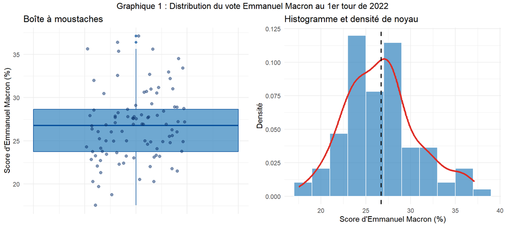

```r
p_box <- ggplot(carte, aes(y = Macron_EXP)) +
  geom_boxplot(fill = "#3182bd", color = "#08519c", alpha = 0.7, width = 0.4) +
  geom_jitter(aes(x = 0), width = 0.1, color = "#08306b", alpha = 0.5, size = 1.8) +
  labs(title = "Boîte à moustaches", y = "Score d'Emmanuel Macron (%)", x = "") +
  theme_minimal() +
  theme(axis.text.x = element_blank())

p_hist <- ggplot(carte, aes(x = Macron_EXP)) +
  geom_histogram(aes(y = after_stat(density)), binwidth = 2, fill = "#3182bd", color = "white", alpha = 0.7) +
  geom_density(color = "#de2d26", linewidth = 1.1) +
  geom_vline(xintercept = mean(carte$Macron_EXP), linetype = "dashed", color = "black", linewidth = 0.8) +
  labs(title = "Histogramme et densité de noyau", x = "Score d'Emmanuel Macron (%)", y = "Densité") +
  theme_minimal()

gridExtra::grid.arrange(p_box, p_hist, ncol = 2, top = "Graphique 1 : Distribution du vote Emmanuel Macron au 1er tour de 2022")
```

La distribution est unimodale, relativement symétrique autour de 27-28 %, avec une légère traîne vers les valeurs élevées correspondant aux métropoles franciliennes.

## 3.2 Cartographie de la géographie électorale et territoriale

Visualisons la géographie électorale et les caractéristiques structurelles majeures :

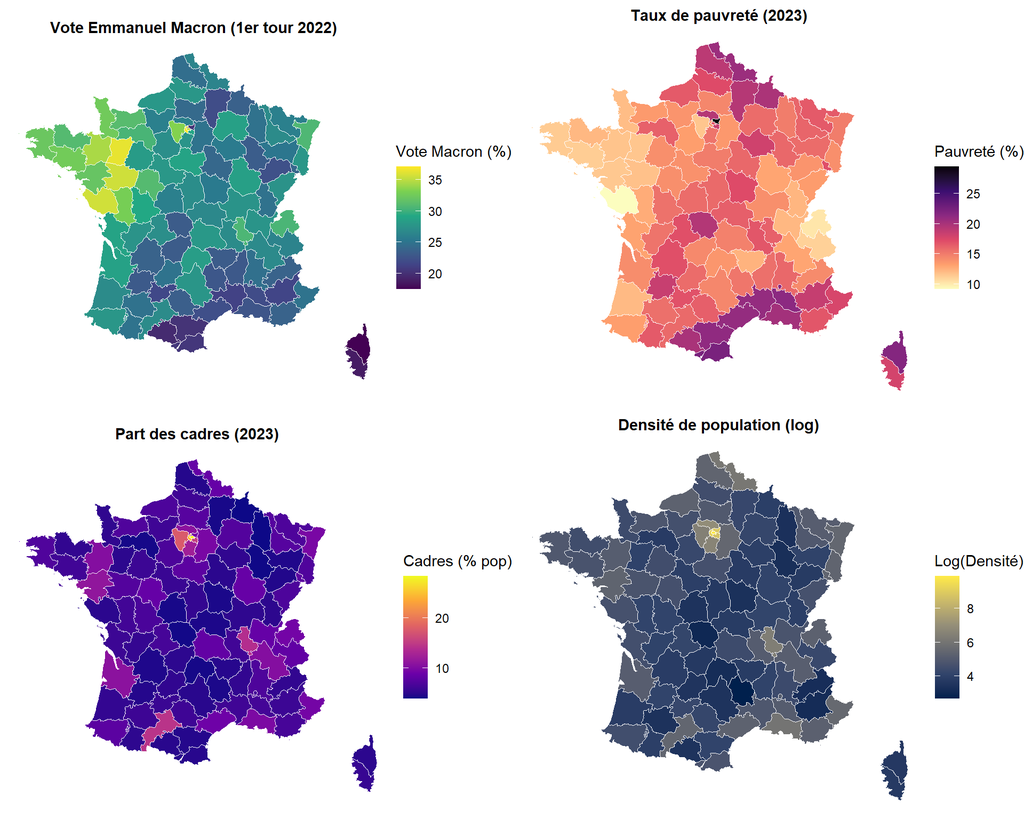

```r
c1 <- ggplot(carte) +
  geom_sf(aes(fill = Macron_EXP), color = "white", linewidth = 0.15) +
  scale_fill_viridis_c(option = "viridis", direction = 1, name = "Vote Macron (%)") +
  labs(title = "Vote Emmanuel Macron (1er tour 2022)") +
  theme_void() +
  theme(plot.title = element_text(face = "bold", size = 11, hjust = 0.5))

c2 <- ggplot(carte) +
  geom_sf(aes(fill = pauvrete), color = "white", linewidth = 0.15) +
  scale_fill_viridis_c(option = "magma", direction = -1, name = "Pauvreté (%)") +
  labs(title = "Taux de pauvreté (2023)") +
  theme_void() +
  theme(plot.title = element_text(face = "bold", size = 11, hjust = 0.5))

c3 <- ggplot(carte) +
  geom_sf(aes(fill = cadres_pct), color = "white", linewidth = 0.15) +
  scale_fill_viridis_c(option = "plasma", direction = 1, name = "Cadres (% pop)") +
  labs(title = "Part des cadres (2023)") +
  theme_void() +
  theme(plot.title = element_text(face = "bold", size = 11, hjust = 0.5))

c4 <- ggplot(carte) +
  geom_sf(aes(fill = ldens), color = "white", linewidth = 0.15) +
  scale_fill_viridis_c(option = "cividis", direction = 1, name = "Log(Densité)") +
  labs(title = "Densité de population (log)") +
  theme_void() +
  theme(plot.title = element_text(face = "bold", size = 11, hjust = 0.5))

gridExtra::grid.arrange(c1, c2, c3, c4, ncol = 2)
```

**Constats visuels immédiats :** * Le vote Macron présente une concentration remarquable sur la façade atlantique et l’Ouest armoricain (Bretagne, Pays de la Loire, Manche), traditionnellement modérés, catholiques sociaux et économiquement dynamiques. * À l’inverse, une vaste zone de sous-performance s’étend sur le Nord-Est minier et métallurgique (Hauts-de-France, Ardennes), les contreforts orientaux et le pourtour méditerranéen. * La pauvreté est très forte dans le Nord, le Sud méditerranéen et la Seine-Saint-Denis, zones de relative faiblesse pour Macron.

# 4 Analyse descriptive bivariée et matrices de corrélation classiques

## 4.1 Nuages de points et associations linéaires bivariées

Examinons les relations linéaires entre le score de Macron et ses potentiels déterminants :

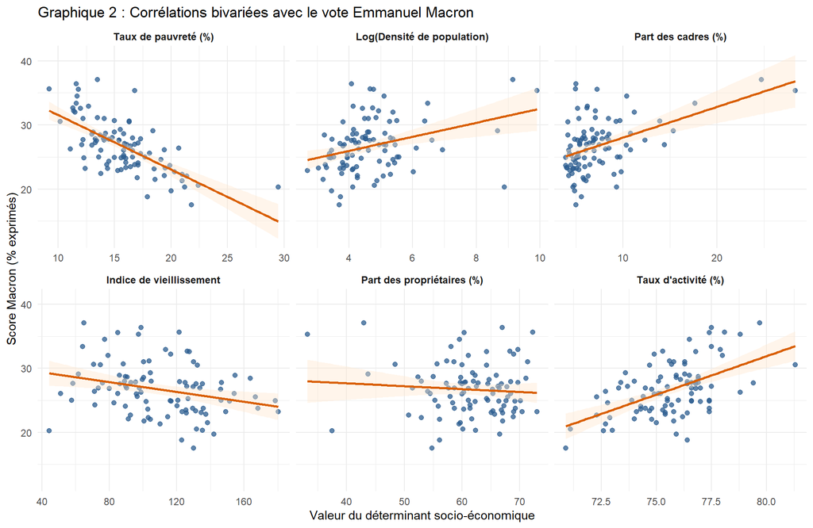

```r
facteurs_cles <- c("pauvrete", "ldens", "cadres_pct", "vieillissement", "proprietaires", "activite")
labels_cles <- c(pauvrete = "Taux de pauvreté (%)",
                 ldens = "Log(Densité de population)",
                 cadres_pct = "Part des cadres (%)",
                 vieillissement = "Indice de vieillissement",
                 proprietaires = "Part des propriétaires (%)",
                 activite = "Taux d'activité (%)")

df_nuages <- carte %>%
  st_drop_geometry() %>%
  select(Macron_EXP, all_of(facteurs_cles)) %>%
  pivot_longer(-Macron_EXP, names_to = "Facteur", values_to = "Valeur") %>%
  mutate(Facteur_Label = factor(Facteur, levels = facteurs_cles, labels = labels_cles[facteurs_cles]))

ggplot(df_nuages, aes(x = Valeur, y = Macron_EXP)) +
  geom_point(color = "#2b5c8f", alpha = 0.75, size = 1.8) +
  geom_smooth(method = "lm", formula = y ~ x, color = "#d95f02", fill = "#fee6ce", linewidth = 1) +
  facet_wrap(~ Facteur_Label, scales = "free_x", ncol = 3) +
  labs(title = "Graphique 2 : Corrélations bivariées avec le vote Emmanuel Macron",
       y = "Score Macron (% exprimés)", x = "Valeur du déterminant socio-économique") +
  theme_minimal() +
  theme(strip.text = element_text(face = "bold", size = 9))
```

## 4.2 Matrice de corrélation complète classique

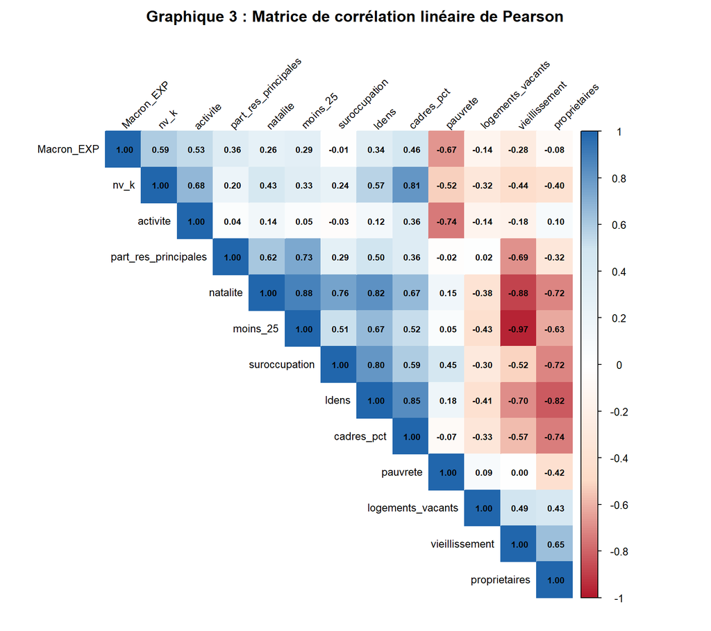

```r
vars_mat_corr <- c("Macron_EXP", "pauvrete", "ldens", "cadres_pct", "nv_k",
                   "vieillissement", "proprietaires", "activite", "logements_vacants",
                   "suroccupation", "natalite", "moins_25", "part_res_principales")

mat_cor_pearson <- cor(carte %>% st_drop_geometry() %>% select(all_of(vars_mat_corr)), use = "pairwise.complete.obs")

corrplot(mat_cor_pearson, method = "color", type = "upper", order = "hclust",
         tl.col = "black", tl.srt = 45, tl.cex = 0.8,
         addCoef.col = "black", number.cex = 0.65,
         col = colorRampPalette(c("#b2182b", "#fddbc7", "#ffffff", "#d1e5f0", "#2166ac"))(200),
         title = "Graphique 3 : Matrice de corrélation linéaire de Pearson", mar = c(0, 0, 2, 0))
```

# 5 Modélisation spatiale : matrices de connectivité et de poids $W$

## 5.1 Principes de formalisation spatiale

En économétrie spatiale, l’espace n’est pas une simple coordonnée euclidienne continue, mais une structure de relations mutuelles formellement résumée par une **matrice de poids spatiaux $W$** de dimension $n \times n$ ($96 \times 96$) :

$$W = \begin{pmatrix}
w_{11} & w_{12} & \cdots & w_{1n} \\
w_{21} & w_{22} & \cdots & w_{2n} \\
\vdots & \vdots & \ddots & \vdots \\
w_{n1} & w_{n2} & \cdots & w_{nn}
\end{pmatrix}$$

Les hypothèses conventionnelles du cours sont respectées : 1. **Diagonale nulle :** $w_{ii} = 0$, un département ne peut pas être son propre voisin (absence d’auto-influence directe). 2. **Standardisation en ligne (style `"W"`) :** $\sum_{j=1}^n w_{ij} = 1$ pour tout $i$. La standardisation transforme le produit matriciel $Wy$ en une **moyenne pondérée du phénomène observé chez les voisins** :
$$(Wy)_i = \sum_{j=1}^n w_{ij} y_j$$
3. Cette normalisation assure également que les valeurs propres de $W$ sont bornées supérieurement par 1, ce qui garantit la non-singularité de la matrice $(I - \rho W)$ pour toute valeur de $\rho \in ]1/\omega_{\min}, 1[$.

## 5.2 Construction comparée de 6 matrices de poids

Pour évaluer la robustesse de nos résultats, nous construisons six matrices de voisinage représentatives des pratiques économétriques :

```r
nb_queen <- poly2nb(carte, queen = TRUE, row.names = carte$code_dep)
nb_rook  <- poly2nb(carte, queen = FALSE, row.names = carte$code_dep)
nb_k4    <- knn2nb(knearneigh(centroides, k = 4), row.names = carte$code_dep)
nb_k6    <- knn2nb(knearneigh(centroides, k = 6), row.names = carte$code_dep)

# Calcul du seuil critique
d1 <- unlist(nbdists(knn2nb(knearneigh(centroides, k = 1)), centroides))
d_crit <- max(d1)
nb_seuil <- dnearneigh(centroides, 0, d_crit, row.names = carte$code_dep)

# Distance inverse sur rayon de 250 km
nb_inv <- dnearneigh(centroides, 0, 250000, row.names = carte$code_dep)
dists_inv <- lapply(nbdists(nb_inv, centroides), function(d) 1 / (d / 1000))

W_queen <- nb2listw(nb_queen, style = "W", zero.policy = TRUE)
W_rook  <- nb2listw(nb_rook,  style = "W", zero.policy = TRUE)
W_k4    <- nb2listw(nb_k4,    style = "W")
W_k6    <- nb2listw(nb_k6,    style = "W")
W_seuil <- nb2listw(nb_seuil, style = "W")
W_inv   <- nb2listw(nb_inv, glist = dists_inv, style = "W")

liste_structures <- list("Queen" = nb_queen, "Rook" = nb_rook, "kNN-4" = nb_k4,
                        "kNN-6" = nb_k6, "Seuil distance" = nb_seuil, "Distance inverse (250km)" = nb_inv)

resume_w <- do.call(rbind, lapply(names(liste_structures), function(nom) {
  nb <- liste_structures[[nom]]
  cartes_voisins <- card(nb)
  data.frame(Structure = nom,
             Liens_Totaux = sum(cartes_voisins),
             Voisins_Moyens = round(mean(cartes_voisins), 2),
             Min_Voisins = min(cartes_voisins),
             Max_Voisins = max(cartes_voisins),
             Sous_Graphes = n.comp.nb(nb)$nc,
             Symetrique = is.symmetric.nb(nb, verbose = FALSE, force = TRUE),
             check.names = FALSE)
}))

kable(resume_w, caption = "Tableau 2 : Propriétés topologiques comparées des matrices de poids spatiales")
```

Tableau 2 : Propriétés topologiques comparées des matrices de poids spatiales

| Structure | Liens_Totaux | Voisins_Moyens | Min_Voisins | Max_Voisins | Sous_Graphes | Symetrique |
| --- | --- | --- | --- | --- | --- | --- |
| Queen | 480 | 5.00 | 1 | 10 | 2 | TRUE |
| Rook | 472 | 4.92 | 1 | 10 | 2 | TRUE |
| kNN-4 | 384 | 4.00 | 4 | 4 | 1 | FALSE |
| kNN-6 | 576 | 6.00 | 6 | 6 | 1 | FALSE |
| Seuil distance | 374 | 3.90 | 1 | 10 | 3 | TRUE |
| Distance inverse (250km) | 2250 | 23.44 | 1 | 37 | 1 | TRUE |

## 5.3 Représentation cartographique des graphes de voisinage

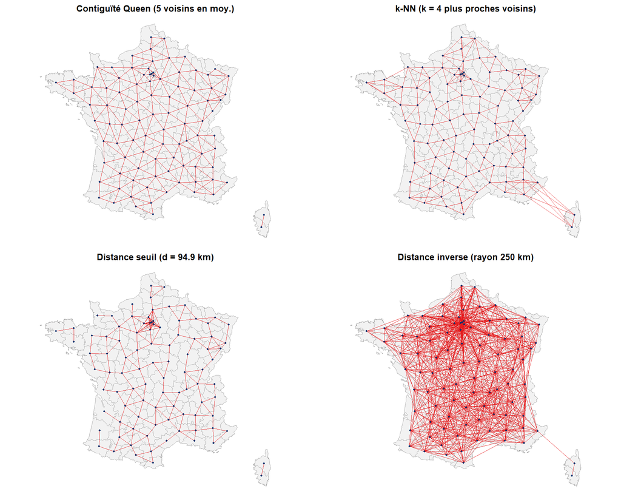

```r
plot_graphe <- function(nb, titre) {
  lignes_sf <- st_as_sf(nb2lines(nb, coords = centroides, proj4string = st_crs(carte)$wkt))
  ggplot() +
    geom_sf(data = carte, fill = "grey95", color = "grey65", linewidth = 0.2) +
    geom_sf(data = lignes_sf, color = "#e41a1c", linewidth = 0.35, alpha = 0.75) +
    geom_sf(data = st_sf(geometry = centroides), color = "#08306b", size = 0.8) +
    labs(title = titre) +
    theme_void() +
    theme(plot.title = element_text(face = "bold", size = 10, hjust = 0.5))
}

g_q  <- plot_graphe(nb_queen, "Contiguïté Queen (5 voisins en moy.)")
g_k4 <- plot_graphe(nb_k4, "k-NN (k = 4 plus proches voisins)")
g_s  <- plot_graphe(nb_seuil, sprintf("Distance seuil (d = %.1f km)", d_crit/1000))
g_inv<- plot_graphe(nb_inv, "Distance inverse (rayon 250 km)")

gridExtra::grid.arrange(g_q, g_k4, g_s, g_inv, ncol = 2)
```

Affichons l’intégralité de la matrice de connectivité spatiale $W$ sous forme de grille matricielle haute résolution. Pour rendre cette matrice parlante, les 96 départements sont classés par leur code géographique :

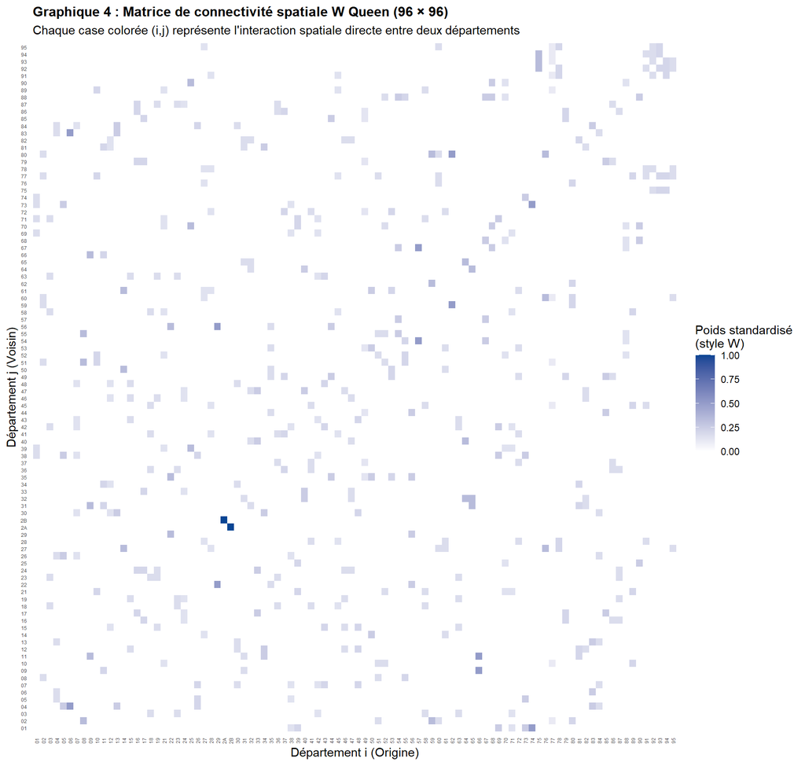

```r
# Extraction de la matrice W dense
W_dense <- nb2mat(nb_queen, style = "W", zero.policy = TRUE)
dimnames(W_dense) <- list(carte$code_dep, carte$code_dep)

df_w_long <- as.data.frame(as.table(W_dense))
names(df_w_long) <- c("Dep_Origine", "Dep_Voisin", "Poids")
df_w_long$Poids_Num <- as.numeric(df_w_long$Poids)

ggplot(df_w_long, aes(x = Dep_Origine, y = Dep_Voisin, fill = Poids_Num)) +
  geom_tile() +
  scale_fill_gradient(low = "white", high = "#084594", name = "Poids standardisé
(style W)") +
  labs(title = "Graphique 4 : Matrice de connectivité spatiale W Queen (96 × 96)",
       subtitle = "Chaque case colorée (i,j) représente l'interaction spatiale directe entre deux départements",
       x = "Département i (Origine)", y = "Département j (Voisin)") +
  theme_minimal() +
  theme(axis.text.x = element_text(size = 4.5, angle = 90, vjust = 0.5, hjust = 1),
        axis.text.y = element_text(size = 4.5),
        panel.grid = element_blank(),
        plot.title = element_text(face = "bold", size = 12))
```

## 5.5 Le retard spatial (*Spatial Lag*)

Le retard spatial d’Emmanuel Macron, noté $W \times \text{Macron\_EXP}$, est calculé en multipliant la matrice $W_{\text{Queen}}$ par le vecteur des scores :

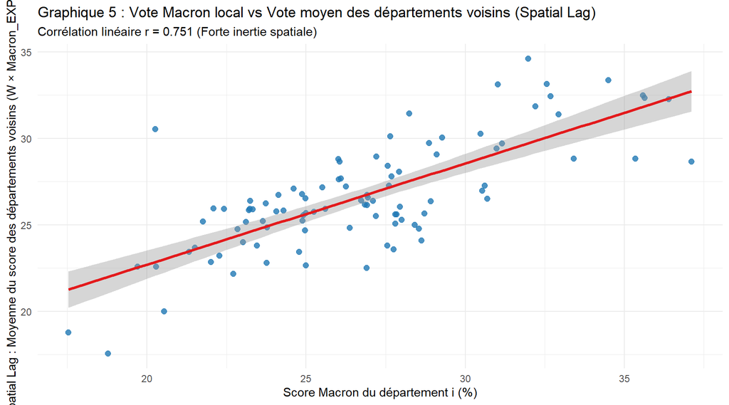

```r
carte$lag_macron <- lag.listw(W_queen, carte$Macron_EXP, zero.policy = TRUE)

cor_lag <- cor(carte$Macron_EXP, carte$lag_macron)

ggplot(carte, aes(x = Macron_EXP, y = lag_macron)) +
  geom_point(color = "#1f78b4", size = 2.2, alpha = 0.8) +
  geom_smooth(method = "lm", formula = y ~ x, color = "#e31a1c", linewidth = 1.1) +
  labs(title = "Graphique 5 : Vote Macron local vs Vote moyen des départements voisins (Spatial Lag)",
       subtitle = sprintf("Corrélation linéaire r = %.3f (Forte inertie spatiale)", cor_lag),
       x = "Score Macron du département i (%)",
       y = "Spatial Lag : Moyenne du score des départements voisins (W × Macron_EXP)") +
  theme_minimal()
```

La corrélation linéaire entre le vote d’un département et celui de ses voisins immédiats atteint un niveau impressionnant de **$r = 0.751$**. Cette très forte proximité statistique confirme que le vote pour Emmanuel Macron ne relève pas d’une distribution aléatoire mais obéit à un puissant gradient spatial.

# 6 Analyse exploratoire de l’autocorrélation spatiale (ESDA)

## 6.1 Test global de Moran

L’indice global de Moran teste formellement l’hypothèse nulle $H_0$ d’absence d’autocorrélation spatiale :

$$I = \frac{n}{S_0} \frac{\sum_{i=1}^n
\sum_{j=1}^n w_{ij}(y_i - \bar{y})(y_j - \bar{y})}{\sum_{i=1}^n (y_i -
\bar{y})^2}$$

où $S_0 = \sum_i \sum_j w_{ij} = n$ pour une matrice standardisée en ligne. L’espérance théorique sous $H_0$ est $E[I] = -\frac{1}{n-1} = -\frac{1}{95} \approx -0,0105$.

Nous effectuons le test sous deux approches : analytique (loi normale asymptotique) et non paramétrique par permutations de Monte-Carlo (999 tirages aléatoires) :

```r
y_vote <- carte$Macron_EXP

# Test analytique
test_moran_ana <- moran.test(y_vote, W_queen, randomisation = TRUE)

# Test de Monte-Carlo (999 permutations)
set.seed(2022)
test_moran_mc <- moran.mc(y_vote, W_queen, nsim = 999)

test_moran_ana
```

```
##
##  Moran I test under randomisation
##
## data:  y_vote
## weights: W_queen
##
## Moran I statistic standard deviate = 8.8607, p-value < 2.2e-16
## alternative hypothesis: greater
## sample estimates:
## Moran I statistic       Expectation          Variance
##       0.585778925      -0.010526316       0.004529009
```

```r
test_moran_mc
```

```
##
##  Monte-Carlo simulation of Moran I
##
## data:  y_vote
## weights: W_queen
## number of simulations + 1: 1000
##
## statistic = 0.58578, observed rank = 1000, p-value = 0.001
## alternative hypothesis: greater
```

**Interprétation statistique :** * L’indice de Moran observé vaut **$I = 0.5858$**, très largement supérieur à son espérance théorique ($E[I] = -0.0105$). * L’écart-type standardisé vaut **$z = 8.861$**, associé à une p-value analytique de **$p < 2,2 \times 10^{-16}$**. * Dans le test de Monte-Carlo, sur 1 000 configurations (999 permutations aléatoires + la valeur observée), aucune permutation n’atteint la valeur observée ($p = 0,001$).

L’hypothèse d’indépendance spatiale est donc rejetée avec une certitude absolue. Il existe une **autocorrélation spatiale positive hautement significative** dans le vote Macron.

## 6.2 Diagramme de dispersion de Moran (*Moran Scatterplot*)

Le diagramme de Moran projette la variable standardisée $z = \frac{y - \bar{y}}{\sigma_y}$ en abscisse et son retard spatial standardisé $Wz$ en ordonnée. La pente de la droite de régression MCO sans constante est égale à l’indice $I$ de Moran. Le plan se divise en 4 quadrants :

- **Q1 (En haut à droite - High-High) :** Départements à fort vote Macron entourés de départements à fort vote (points chauds).
- **Q2 (En bas à gauche - Low-Low) :** Départements à faible vote Macron entourés de départements à faible vote (points froids).
- **Q3 (En bas à droite - High-Low) :** Départements à vote élevé entourés de départements à faible vote (atypiques spatiaux).
- **Q4 (En haut à gauche - Low-High) :** Départements à faible vote entourés de départements à vote élevé (atypiques spatiaux).

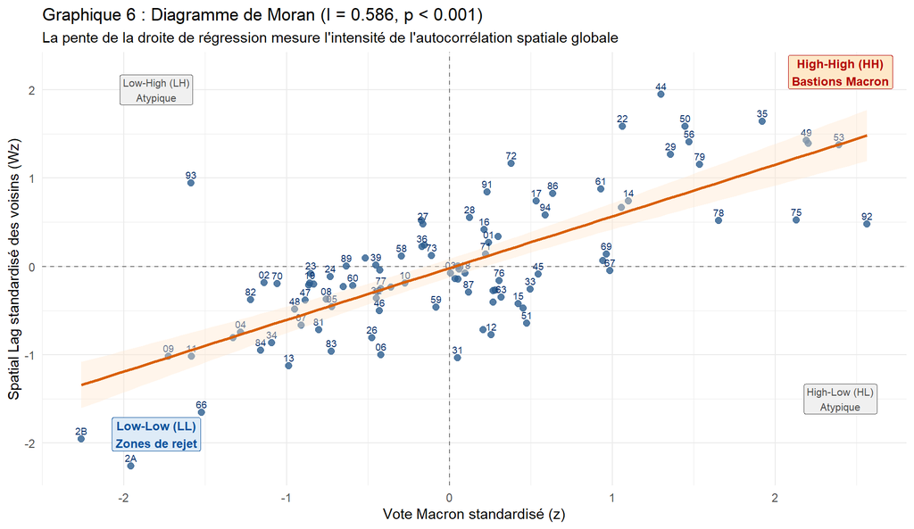

```r
z_vote <- as.numeric(scale(y_vote))
wz_vote <- lag.listw(W_queen, z_vote, zero.policy = TRUE)

df_moran_scatter <- data.frame(z = z_vote, wz = wz_vote, code_dep = carte$code_dep, nom = carte$departement)

ggplot(df_moran_scatter, aes(x = z, y = wz, label = code_dep)) +
  geom_hline(yintercept = 0, linetype = "dashed", color = "grey50") +
  geom_vline(xintercept = 0, linetype = "dashed", color = "grey50") +
  geom_point(color = "#2b5c8f", size = 2.2, alpha = 0.8) +
  geom_text(size = 2.5, vjust = -0.6, color = "#08306b", check_overlap = TRUE) +
  geom_smooth(method = "lm", formula = y ~ x, color = "#d95f02", fill = "#fee6ce", linewidth = 1) +
  annotate("label", x = 2.4, y = 2.2, label = "High-High (HH)
Bastions Macron", fill = "#fee8c8", color = "#b30000", fontface = "bold", size = 3.2) +
  annotate("label", x = -1.8, y = -1.9, label = "Low-Low (LL)
Zones de rejet", fill = "#deebf7", color = "#08519c", fontface = "bold", size = 3.2) +
  annotate("label", x = 2.4, y = -1.5, label = "High-Low (HL)
Atypique", fill = "#f0f0f0", color = "grey30", size = 2.8) +
  annotate("label", x = -1.8, y = 2.0, label = "Low-High (LH)
Atypique", fill = "#f0f0f0", color = "grey30", size = 2.8) +
  labs(title = sprintf("Graphique 6 : Diagramme de Moran (I = %.3f, p < 0.001)", test_moran_ana$estimate[1]),
       subtitle = "La pente de la droite de régression mesure l'intensité de l'autocorrélation spatiale globale",
       x = "Vote Macron standardisé (z)",
       y = "Spatial Lag standardisé des voisins (Wz)") +
  theme_minimal()
```

L’écrasante majorité des départements se situe dans les quadrants HH et LL, matérialisant l’intensité du regroupement spatial.

## 6.3 Indices globaux complémentaires : C de Geary et G de Getis-Ord

Le $C$ de Geary s’intéresse aux différences au carré entre voisins ($C < 1$ signale une autocorrélation positive, $C > 1$ négative) :

$$C = \frac{n-1}{2 S_0} \frac{\sum_i
\sum_j w_{ij}(y_i - y_j)^2}{\sum_i (y_i - \bar{y})^2}$$

```r
test_geary <- geary.test(y_vote, W_queen, zero.policy = TRUE)
test_geary
```

```
##
##  Geary C test under randomisation
##
## data:  y_vote
## weights: W_queen
##
## Geary C statistic standard deviate = 8.4071, p-value < 2.2e-16
## alternative hypothesis: Expectation greater than statistic
## sample estimates:
## Geary C statistic       Expectation          Variance
##       0.412382436       1.000000000       0.004885369
```

L’indice de Geary vaut **$C = 0.4124$** ($p < 2,2 \times 10^{-16}$), confirmant que les départements limitrophes ont des scores très proches.

## 6.4 Robustesse de l’autocorrélation spatiale selon la matrice de poids

L’autocorrélation constatée dépend-elle du choix de la matrice de poids ? Nous répliquons le test de Moran sur les 6 matrices de connectivité :

```r
liste_w_test <- list("Queen (Reine)" = W_queen,
                     "Rook (Tour)" = W_rook,
                     "kNN-4 (4 voisins)" = W_k4,
                     "kNN-6 (6 voisins)" = W_k6,
                     "Seuil critique" = W_seuil,
                     "Distance inverse (250km)" = W_inv)

tab_moran_rob <- do.call(rbind, lapply(names(liste_w_test), function(nom) {
  w_obj <- liste_w_test[[nom]]
  tm <- moran.test(y_vote, w_obj, zero.policy = TRUE)
  tmc <- moran.mc(y_vote, w_obj, nsim = 999, zero.policy = TRUE)
  data.frame(Matrice = nom,
             I_Moran = round(unname(tm$estimate[1]), 4),
             z_score = round(unname(tm$statistic), 3),
             p_analytique = format.pval(tm$p.value, eps = 0.001),
             p_MonteCarlo = format.pval(tmc$p.value, eps = 0.001),
             check.names = FALSE)
}))

kable(tab_moran_rob, caption = "Tableau 3 : Sensibilité du test de Moran global au choix de la matrice de poids")
```

Tableau 3 : Sensibilité du test de Moran global au choix de la matrice de poids

| Matrice | I_Moran | z_score | p_analytique | p_MonteCarlo |
| --- | --- | --- | --- | --- |
| Queen (Reine) | 0.5858 | 8.861 | < 0.001 | 0.001 |
| Rook (Tour) | 0.5857 | 8.762 | < 0.001 | 0.001 |
| kNN-4 (4 voisins) | 0.5673 | 8.695 | < 0.001 | 0.001 |
| kNN-6 (6 voisins) | 0.5206 | 9.849 | < 0.001 | 0.001 |
| Seuil critique | 0.5860 | 7.352 | < 0.001 | 0.001 |
| Distance inverse (250km) | 0.4757 | 13.415 | < 0.001 | 0.001 |

Quelle que soit la matrice retenue (contiguïté, k-NN ou distance continue), l’indice de Moran oscille entre $0,47$ et $0,59$, toujours hautement significatif ($p < 0,001$). Ce résultat démontre la robustesse intrinsèque de la structure spatiale du vote.

## 6.5 Corrélogramme spatial

Le corrélogramme spatial analyse l’évolution de l’indice de Moran lorsque l’on élargit le voisinage aux ordres de contiguïté supérieurs (voisins de voisins, ordres 1 à 5) :

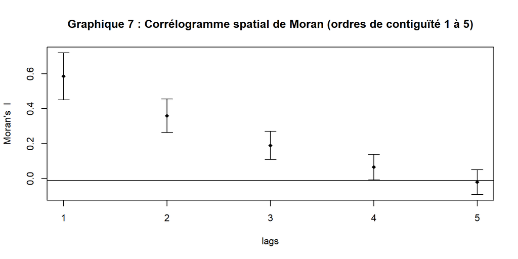

```r
correlog_moran <- sp.correlogram(nb_queen, y_vote, order = 5, method = "I", style = "W", zero.policy = TRUE)
plot(correlog_moran, main = "Graphique 7 : Corrélogramme spatial de Moran (ordres de contiguïté 1 à 5)")
```

L’autocorrélation décroît de manière monotone avec l’ordre de voisinage : forte à l’ordre 1 ($I \approx 0,59$), modérée à l’ordre 2 ($I \approx 0,35$), et tendant vers zéro au-delà de l’ordre 3. Cela valide la première loi de la géographie de Tobler (1970) : *« Toutes choses sont liées entre elles, mais les choses proches sont plus liées que les choses éloignées »*.

## 6.6 Autocorrélation spatiale des variables explicatives

Les variables explicatives sont-elles elles-mêmes autocorrélées dans l’espace ?

```r
vars_x_etudiees <- c("pauvrete", "ldens", "cadres_pct", "vieillissement", "proprietaires",
                     "activite", "nv_k", "logements_vacants", "suroccupation", "natalite")

tab_moran_x <- do.call(rbind, lapply(vars_x_etudiees, function(var) {
  t_m <- moran.test(carte[[var]], W_queen, zero.policy = TRUE)
  data.frame(Variable = var,
             I_Moran = round(unname(t_m$estimate[1]), 4),
             z_score = round(unname(t_m$statistic), 2),
             p_value = format.pval(t_m$p.value, eps = 0.001),
             check.names = FALSE)
}))

kable(tab_moran_x, caption = "Tableau 4 : Test de Moran des variables explicatives (Matrice Queen)")
```

Tableau 4 : Test de Moran des variables explicatives (Matrice Queen)

| Variable | I_Moran | z_score | p_value |
| --- | --- | --- | --- |
| pauvrete | 0.4647 | 7.16 | < 0.001 |
| ldens | 0.6458 | 10.03 | < 0.001 |
| cadres_pct | 0.4284 | 7.00 | < 0.001 |
| vieillissement | 0.5085 | 7.69 | < 0.001 |
| proprietaires | 0.4739 | 7.30 | < 0.001 |
| activite | 0.3094 | 4.77 | < 0.001 |
| nv_k | 0.3031 | 4.82 | < 0.001 |
| logements_vacants | 0.5819 | 8.83 | < 0.001 |
| suroccupation | 0.6423 | 10.95 | < 0.001 |
| natalite | 0.6150 | 9.39 | < 0.001 |

## 6.7 Indicateurs locaux d’association spatiale : les LISA d’Anselin

L’indice local de Moran $I_i$ (Anselin, 1995) décompose l’autocorrélation globale pour chaque unité géographique $i$ :

$$I_i = z_i \sum_{j=1}^n w_{ij}
z_j$$

Il identifie les poches spatiales statistiquement significatives : * **High-High (HH - Hot Spots) :** Démarrent un pôle d’attraction électorale ; * **Low-Low (LL - Cold Spots) :** Foyers de rejet ; * **High-Low (HL) & Low-High (LH) :** Atypiques spatiaux en rupture avec leur voisinage.

Pour tenir compte du risque de faux positifs induit par les tests multiples simultanés (les 96 $I_i$ étant testés conjointement et n’étant pas indépendants), nous calculons à la fois le seuil brut $p < 0,05$ et le seuil corrigé par le taux de fausse découverte (**FDR - False Discovery Rate** de Benjamini-Hochberg) :

```r
lisa_local <- localmoran(y_vote, W_queen, alternative = "two.sided", zero.policy = TRUE)
p_val_col <- grep("^Pr", colnames(lisa_local))[1]

carte$Ii <- lisa_local[, "Ii"]
carte$p_lisa <- lisa_local[, p_val_col]
carte$p_lisa_fdr <- p.adjust(carte$p_lisa, method = "fdr")

# Classification des quadrants
quad_lisa <- ifelse(z_vote >= 0 & wz_vote >= 0, "High-High",
             ifelse(z_vote < 0 & wz_vote < 0, "Low-Low",
             ifelse(z_vote >= 0 & wz_vote < 0, "High-Low", "Low-High")))

carte$lisa_cluster <- factor(ifelse(carte$p_lisa < 0.05, quad_lisa, "Non significatif"),
                            levels = c("High-High", "Low-Low", "High-Low", "Low-High", "Non significatif"))

carte$lisa_cluster_fdr <- factor(ifelse(carte$p_lisa_fdr < 0.05, quad_lisa, "Non significatif"),
                                levels = c("High-High", "Low-Low", "High-Low", "Low-High", "Non significatif"))

cols_lisa_pal <- c("High-High" = "#d7191c", "Low-Low" = "#2c7bb6",
                   "High-Low" = "#fdae61", "Low-High" = "#abd9e9", "Non significatif" = "grey92")

table_lisa_brut <- table(carte$lisa_cluster)
table_lisa_fdr  <- table(carte$lisa_cluster_fdr)
```

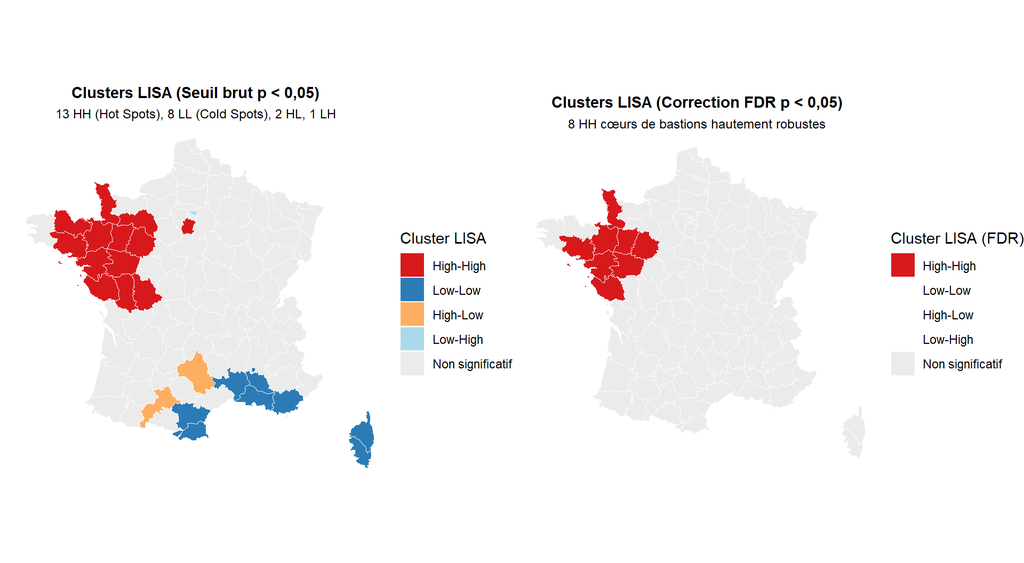

```r
g_lisa1 <- ggplot(carte) +
  geom_sf(aes(fill = lisa_cluster), color = "white", linewidth = 0.15) +
  scale_fill_manual(values = cols_lisa_pal, drop = FALSE, name = "Cluster LISA") +
  labs(title = "Clusters LISA (Seuil brut p < 0,05)",
       subtitle = sprintf("13 HH (Hot Spots), 8 LL (Cold Spots), 2 HL, 1 LH")) +
  theme_void() +
  theme(plot.title = element_text(face = "bold", size = 11, hjust = 0.5),
        plot.subtitle = element_text(size = 9, hjust = 0.5))

g_lisa2 <- ggplot(carte) +
  geom_sf(aes(fill = lisa_cluster_fdr), color = "white", linewidth = 0.15) +
  scale_fill_manual(values = cols_lisa_pal, drop = FALSE, name = "Cluster LISA (FDR)") +
  labs(title = "Clusters LISA (Correction FDR p < 0,05)",
       subtitle = sprintf("8 HH cœurs de bastions hautement robustes")) +
  theme_void() +
  theme(plot.title = element_text(face = "bold", size = 11, hjust = 0.5),
        plot.subtitle = element_text(size = 9, hjust = 0.5))

gridExtra::grid.arrange(g_lisa1, g_lisa2, ncol = 2)
```

```r
tableau_lisa_sig <- carte %>%
  st_drop_geometry() %>%
  filter(lisa_cluster != "Non significatif") %>%
  arrange(lisa_cluster, desc(Macron_EXP)) %>%
  select(Code = code_dep, Département = departement,
         `Vote Macron (%)` = Macron_EXP, `Lag Voisins (%)` = lag_macron,
         `Indice Ii` = Ii, `p-value brute` = p_lisa, `p-value FDR` = p_lisa_fdr,
         Cluster = lisa_cluster)

kable(tableau_lisa_sig, digits = 3, caption = "Tableau 5 : Départements formant les clusters spatiaux locaux significatifs")
```

Tableau 5 : Départements formant les clusters spatiaux locaux significatifs

|  | Code | Département | Vote Macron (%) | Lag Voisins (%) | Indice Ii | p-value brute | p-value FDR | Cluster |
| --- | --- | --- | --- | --- | --- | --- | --- | --- |
| 53 | 53 | Mayenne | 36.40 | 32.276 | 3.316 | 0.001 | 0.019 | High-High |
| 85 | 85 | Vendée | 35.64 | 32.345 | 3.094 | 0.003 | 0.040 | High-High |
| 49 | 49 | Maine-et-Loire | 35.59 | 32.496 | 3.159 | 0.000 | 0.001 | High-High |
| 35 | 35 | Ille-et-Vilaine | 34.50 | 33.373 | 3.191 | 0.000 | 0.001 | High-High |
| 79 | 79 | Deux-Sèvres | 32.94 | 31.390 | 1.793 | 0.007 | 0.065 | High-High |
| 56 | 56 | Morbihan | 32.68 | 32.428 | 2.099 | 0.003 | 0.040 | High-High |
| 50 | 50 | Manche | 32.57 | 33.135 | 2.315 | 0.001 | 0.019 | High-High |
| 44 | 44 | Loire-Atlantique | 31.98 | 34.603 | 2.557 | 0.000 | 0.002 | High-High |
| 22 | 22 | Côtes-d’Armor | 31.02 | 33.130 | 1.702 | 0.005 | 0.053 | High-High |
| 61 | 61 | Orne | 30.48 | 30.272 | 0.826 | 0.025 | 0.139 | High-High |
| 86 | 86 | Vienne | 29.28 | 30.052 | 0.529 | 0.036 | 0.162 | High-High |
| 72 | 72 | Sarthe | 28.24 | 31.432 | 0.445 | 0.003 | 0.040 | High-High |
| 91 | 91 | Essonne | 27.65 | 30.125 | 0.198 | 0.033 | 0.162 | High-High |
| 83 | 83 | Var | 23.77 | 22.808 | 0.703 | 0.048 | 0.193 | Low-Low |
| 13 | 13 | Bouches-du-Rhône | 22.71 | 22.152 | 1.118 | 0.021 | 0.124 | Low-Low |
| 84 | 84 | Vaucluse | 22.01 | 22.852 | 1.112 | 0.015 | 0.114 | Low-Low |
| 30 | 30 | Gard | 21.32 | 23.437 | 1.082 | 0.037 | 0.162 | Low-Low |
| 66 | 66 | Pyrénées-Orientales | 20.54 | 20.000 | 2.540 | 0.016 | 0.114 | Low-Low |
| 11 | 11 | Aude | 20.29 | 22.580 | 1.626 | 0.017 | 0.114 | Low-Low |
| 2A | 2A | Corse-du-Sud | 18.78 | 17.540 | 4.463 | 0.020 | 0.124 | Low-Low |
| 2B | 2B | Haute-Corse | 17.54 | 18.780 | 4.463 | 0.042 | 0.175 | Low-Low |
| 12 | 12 | Aveyron | 27.75 | 23.580 | -0.200 | 0.036 | 0.162 | High-Low |
| 31 | 31 | Haute-Garonne | 26.91 | 22.515 | -0.052 | 0.009 | 0.081 | High-Low |
| 93 | 93 | Seine-Saint-Denis | 20.27 | 30.528 | -1.511 | 0.032 | 0.162 | Low-High |

## 6.8 Statistique locale $G_i^*$ de Getis-Ord

En complément, la statistique $G_i^*$ (incluant l’unité elle-même dans son voisinage via $W^*$) permet de vérifier la robustesse des hot spots :

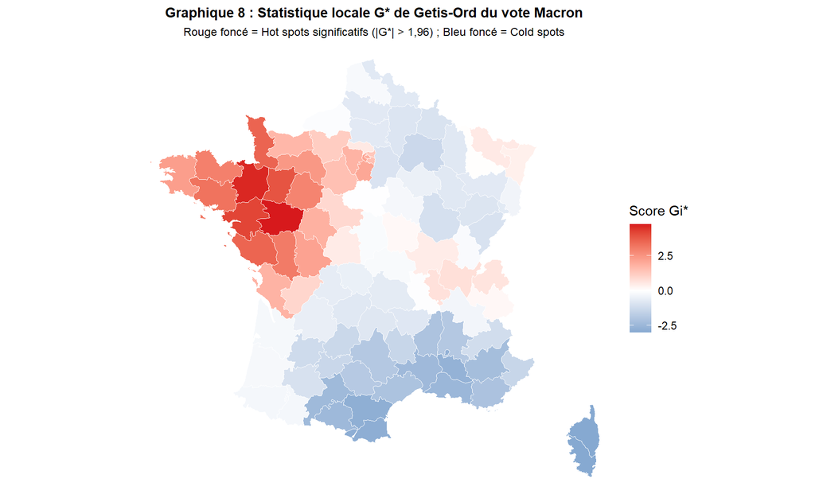

```r
nb_self <- include.self(nb_queen)
W_star <- nb2listw(nb_self, style = "W")
carte$Gi_star <- as.numeric(localG(y_vote, W_star))

ggplot(carte) +
  geom_sf(aes(fill = Gi_star), color = "white", linewidth = 0.15) +
  scale_fill_gradient2(low = "#2c7bb6", mid = "white", high = "#d7191c",
                       midpoint = 0, name = "Score Gi*") +
  labs(title = "Graphique 8 : Statistique locale G* de Getis-Ord du vote Macron",
       subtitle = "Rouge foncé = Hot spots significatifs (|G*| > 1,96) ; Bleu foncé = Cold spots") +
  theme_void() +
  theme(plot.title = element_text(face = "bold", size = 11, hjust = 0.5),
        plot.subtitle = element_text(size = 9, hjust = 0.5))
```

# 7 La matrice de corrélation spatiale intégrale

## 7.1 Matrice de corrélation bivariée spatiale croisée ($Y, WY, X, WX$)

Calculons les variables retardées spatialement pour les 6 déterminants majeurs de l’étude (`W_pauvrete`, `W_ldens`, `W_cadres`, `W_vieillissement`, `W_proprietaires`, `W_activite`) et construisons la grande matrice de corrélation :

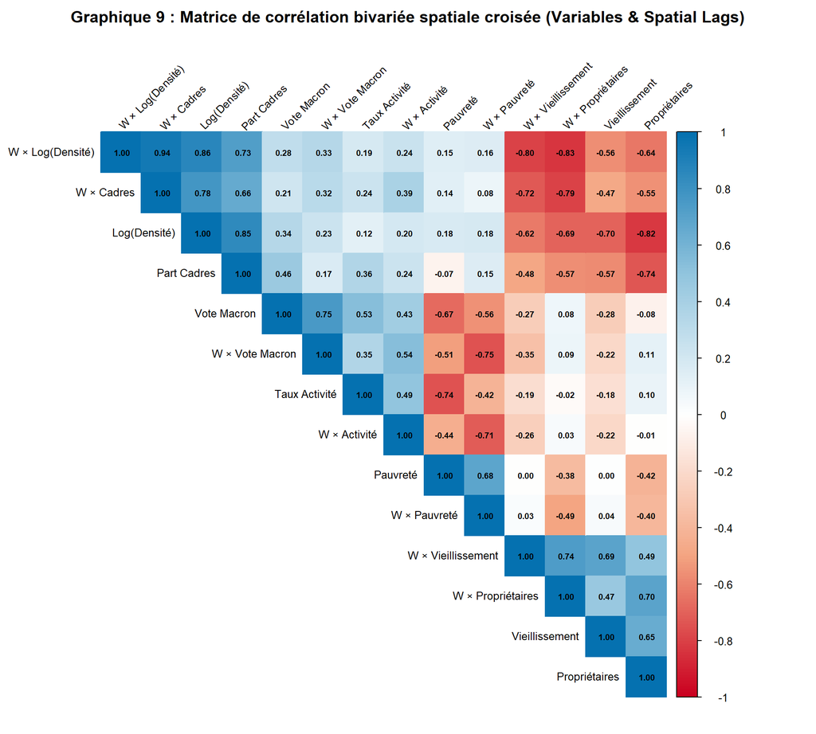

```r
vars_principales <- c("pauvrete", "ldens", "cadres_pct", "vieillissement", "proprietaires", "activite")

# Calcul des spatial lags
for (v in vars_principales) {
  carte[[paste0("W_", v)]] <- lag.listw(W_queen, carte[[v]], zero.policy = TRUE)
}

vars_pour_matrice_spatiale <- c("Macron_EXP", "lag_macron",
                                vars_principales,
                                paste0("W_", vars_principales))

labels_croises <- c(Macron_EXP = "Vote Macron",
                    lag_macron = "W × Vote Macron",
                    pauvrete = "Pauvreté",
                    W_pauvrete = "W × Pauvreté",
                    ldens = "Log(Densité)",
                    W_ldens = "W × Log(Densité)",
                    cadres_pct = "Part Cadres",
                    W_cadres_pct = "W × Cadres",
                    vieillissement = "Vieillissement",
                    W_vieillissement = "W × Vieillissement",
                    proprietaires = "Propriétaires",
                    W_proprietaires = "W × Propriétaires",
                    activite = "Taux Activité",
                    W_activite = "W × Activité")

mat_complete_spatiale <- cor(carte %>% st_drop_geometry() %>% select(all_of(vars_pour_matrice_spatiale)),
                             use = "pairwise.complete.obs")

colnames(mat_complete_spatiale) <- labels_croises[colnames(mat_complete_spatiale)]
rownames(mat_complete_spatiale) <- labels_croises[rownames(mat_complete_spatiale)]

corrplot(mat_complete_spatiale, method = "color", type = "upper", order = "hclust",
         tl.col = "black", tl.srt = 45, tl.cex = 0.8,
         addCoef.col = "black", number.cex = 0.6,
         col = colorRampPalette(c("#ca0020", "#f4a582", "#ffffff", "#92c5de", "#0571b0"))(200),
         title = "Graphique 9 : Matrice de corrélation bivariée spatiale croisée (Variables & Spatial Lags)",
         mar = c(0, 0, 2, 0))
```

Dans un modèle autorégressif spatial de paramètre $\rho$, la matrice de variance-covariance des observations est donnée par :

$$\text{Var}(Y) = \sigma^2 (I - \rho
W)^{-1} (I - \rho W')^{-1} = \sigma^2 V$$

$$R_{ij} = \frac{V_{ij}}{\sqrt{V_{ii}
V_{jj}}}$$

Cette matrice quantifie le niveau de corrélation spatiale entre **chaque couple de départements français** ($i, j$). Calculons cette matrice pour $\hat{\rho} \approx 0,55$ (la valeur estimée dans le modèle SDM ci-après) et traçons sa représentation intégrale :

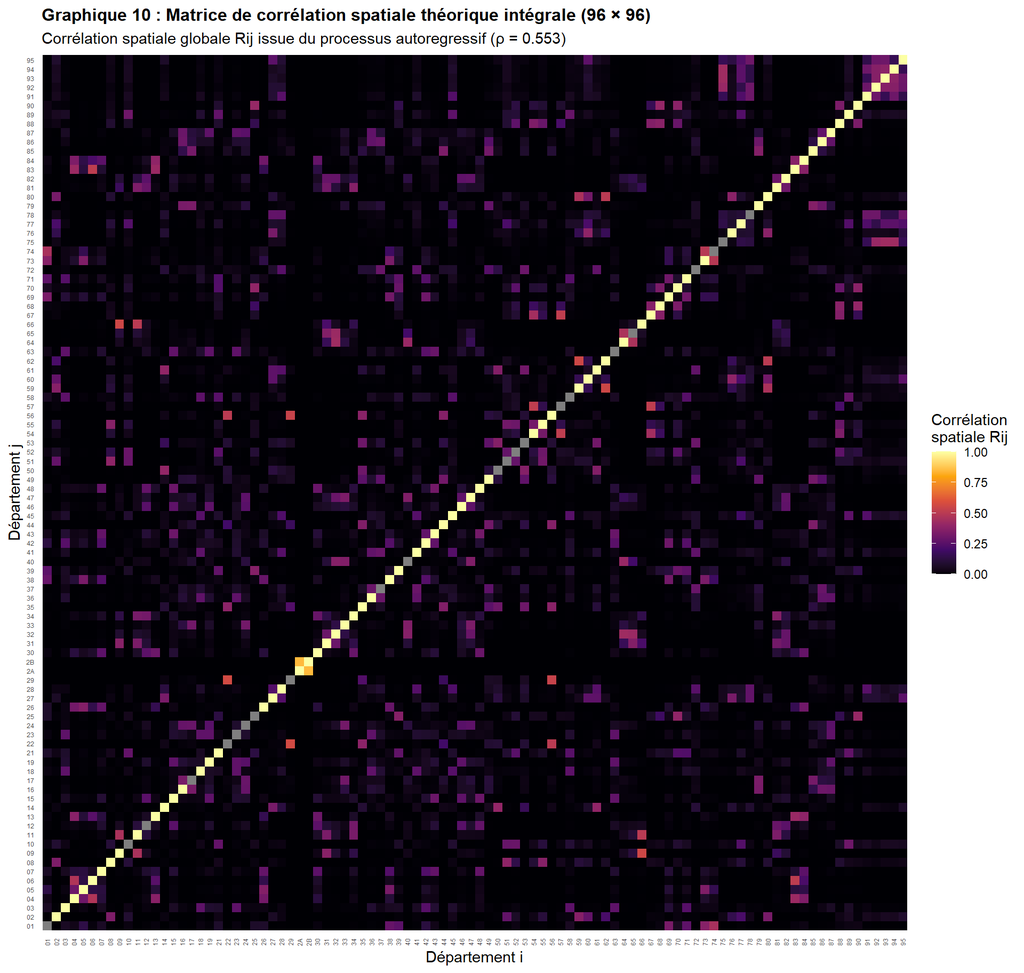

```r
# Paramètre estimé du modèle SDM
rho_estim <- 0.553

W_mat_dense <- nb2mat(nb_queen, style = "W", zero.policy = TRUE)
dimnames(W_mat_dense) <- list(carte$code_dep, carte$code_dep)

# Calcul du multiplicateur spatial (I - rho W)^(-1)
A_mat <- diag(nrow(carte)) - rho_estim * W_mat_dense
A_inv <- solve(A_mat)
V_cov <- A_inv %*% t(A_inv)

# Standardisation en matrice de corrélation
D_inv_diag <- diag(1 / sqrt(diag(V_cov)))
R_corr_spatiale <- D_inv_diag %*% V_cov %*% D_inv_diag
dimnames(R_corr_spatiale) <- list(carte$code_dep, carte$code_dep)

# Conversion en format long pour ggplot
df_corr_long <- as.data.frame(as.table(R_corr_spatiale))
names(df_corr_long) <- c("Dep_i", "Dep_j", "Correlation")
df_corr_long$Correlation <- as.numeric(df_corr_long$Correlation)

ggplot(df_corr_long, aes(x = Dep_i, y = Dep_j, fill = Correlation)) +
  geom_raster() +
  scale_fill_viridis_c(option = "inferno", direction = 1,
                       name = "Corrélation
spatiale Rij", limits = c(0, 1)) +
  labs(title = "Graphique 10 : Matrice de corrélation spatiale théorique intégrale (96 × 96)",
       subtitle = "Corrélation spatiale globale Rij issue du processus autoregressif (ρ = 0.553)",
       x = "Département i", y = "Département j") +
  theme_minimal() +
  theme(axis.text.x = element_text(size = 4.5, angle = 90, vjust = 0.5, hjust = 1),
        axis.text.y = element_text(size = 4.5),
        panel.grid = element_blank(),
        plot.title = element_text(face = "bold", size = 12))
```

**Lecture approfondie :** * Sur la diagonale, la corrélation est égale à 1 ($R_{ii} = 1$). * Pour les voisins immédiats au premier ordre, la corrélation spatiale moyenne est de **$0.316$**. * Même pour des départements non contigus, la corrélation reste positive et décroît au fur et à mesure que la distance sur le réseau de contiguïté augmente (diffusion via $W^2, W^3, \dots$). * Remarquons la séparation de la Corse (codes 2A et 2B), dont la corrélation spatiale avec les départements continentaux est nulle sous contiguïté pure, traduisant son statut d’île.

# 8 Économétrie spatiale : modélisation et sélection du modèle optimal

## 8.1 Sélection des variables explicatives et diagnostic de multicolinéarité

Pour modéliser le vote, nous devons choisir un jeu de régresseurs satisfaisant deux contraintes contradictoires : 1. **L’exhaustivité socio-économique :** Couvrir la pauvreté, le capital humain, la structure démographique, le marché du travail et le type de territoire ; 2. **La parcimonie paramétrique :** Avec seulement $n = 96$ observations, un modèle comme le SDM estime $2K + 3$ paramètres (les $\beta$, les $\theta$, $\rho$, $\sigma^2$ et la constante). Un nombre excessif de variables entraînerait une perte sévère de degrés de liberté et une colinéarité catastrophique entre les variables et leurs retards spatiaux $WX$.

Nous diagnostiquons le facteur d’inflation de la variance (**VIF - Variance Inflation Factor**) sur le modèle incluant l’ensemble des 12 indicateurs, puis sur notre spécification raisonnée :

```r
formule_tous <- reformulate(vars_mat_corr[-1], "Macron_EXP")
vif_tous_indic <- vif(lm(formule_tous, data = carte))

# Spécification théorique retenue : 6 dimensions clés
vars_selectionnees <- c("pauvrete", "ldens", "cadres_pct", "vieillissement", "proprietaires", "activite")
formule_retenue <- reformulate(vars_selectionnees, "Macron_EXP")
vif_modele_retenu <- vif(lm(formule_retenue, data = carte))

tab_vif_comp <- data.frame(Variable = names(vif_tous_indic),
                           `VIF (Tous les 12 indicateurs)` = round(vif_tous_indic, 2),
                           `VIF (Jeu retenu de 6 variables)` = round(vif_modele_retenu[names(vif_tous_indic)], 2),
                           check.names = FALSE, row.names = NULL)

kable(tab_vif_comp, caption = "Tableau 6 : Facteurs d'inflation de variance (VIF) avant et après sélection raisonnée")
```

Tableau 6 : Facteurs d’inflation de variance (VIF) avant et après sélection raisonnée

| Variable | VIF (Tous les 12 indicateurs) | VIF (Jeu retenu de 6 variables) |
| --- | --- | --- |
| pauvrete | 9.52 | 3.65 |
| ldens | 12.48 | 6.27 |
| cadres_pct | 12.89 | 6.50 |
| nv_k | 12.38 | NA |
| vieillissement | 37.60 | 2.49 |
| proprietaires | 7.37 | 6.07 |
| activite | 5.39 | 2.86 |
| logements_vacants | 2.44 | NA |
| suroccupation | 6.27 | NA |
| natalite | 14.51 | NA |
| moins_25 | 45.18 | NA |
| part_res_principales | 4.24 | NA |

Dans le modèle initial à 12 variables, les VIF atteignaient des sommets critiques ($45,2$ pour les moins de 25 ans, $37,6$ pour le vieillissement, $14,5$ pour la natalité, $12,9$ pour les cadres), témoignant d’une multicolinéarité aiguë.

Dans notre spécification à 6 variables (`pauvrete`, `ldens`, `cadres_pct`, `vieillissement`, `proprietaires`, `activite`), tous les VIF sont bien maîtrisés (inférieurs à 6,5, sous les seuils d’alerte habituels de 5 à 10). Chaque dimension socio-électorale majeure est préservée sans redondance.

## 8.2 Modèle MCO classique et diagnostics sur les résidus

Commençons par estimer le modèle linéaire standard par les Moindres Carrés Ordinaires (MCO) :

$$Y = X \beta + \varepsilon, \quad
\varepsilon \sim \mathcal{N}(0, \sigma^2 I_n)$$

```r
modele_ols <- lm(formule_retenue, data = carte)
summary(modele_ols)
```

```
##
## Call:
## lm(formula = formule_retenue, data = carte)
##
## Residuals:
##     Min      1Q  Median      3Q     Max
## -4.9381 -1.2204 -0.0904  1.5522  7.1482
##
## Coefficients:
##                Estimate Std. Error t value Pr(>|t|)
## (Intercept)    78.85359   18.69610   4.218 5.92e-05 ***
## pauvrete       -1.24083    0.14109  -8.794 1.00e-13 ***
## ldens           1.76143    0.47162   3.735 0.000331 ***
## cadres_pct      0.02964    0.15551   0.191 0.849259
## vieillissement  0.01815    0.01269   1.430 0.156314
## proprietaires  -0.04536    0.08136  -0.558 0.578557
## activite       -0.53283    0.22137  -2.407 0.018151 *
## ---
## Signif. codes:  0 '***' 0.001 '**' 0.01 '*' 0.05 '.' 0.1 ' ' 1
##
## Residual standard error: 2.302 on 89 degrees of freedom
## Multiple R-squared:  0.6981, Adjusted R-squared:  0.6778
## F-statistic:  34.3 on 6 and 89 DF,  p-value: < 2.2e-16
```

```r
carte$residus_ols <- residuals(modele_ols)
```

### 8.2.1 Diagnostics économétriques sur les résidus MCO

```r
# Test d'hétéroscédasticité de Breusch-Pagan
test_bp <- bptest(modele_ols)

# Test de normalité de Shapiro-Wilk
test_shapiro <- shapiro.test(residuals(modele_ols))

# Test d'autocorrélation spatiale de Moran sur les résidus
test_moran_res_ols <- moran.test(residuals(modele_ols), W_queen, zero.policy = TRUE)

data.frame(Diagnostic = c("Hétéroscédasticité (Breusch-Pagan)", "Normalité (Shapiro-Wilk)", "Autocorrélation spatiale (Moran sur résidus)"),
           Statistique = c(round(test_bp$statistic, 3), round(test_shapiro$statistic, 3), round(test_moran_res_ols$estimate[1], 3)),
           p_value = c(format.pval(test_bp$p.value, eps = 0.001), format.pval(test_shapiro$p.value, eps = 0.001), format.pval(test_moran_res_ols$p.value, eps = 0.001))) %>%
  kable(caption = "Tableau 7 : Diagnostics économétriques sur les résidus de la régression MCO")
```

Tableau 7 : Diagnostics économétriques sur les résidus de la régression MCO

|  | Diagnostic | Statistique | p_value |
| --- | --- | --- | --- |
| BP | Hétéroscédasticité (Breusch-Pagan) | 10.623 | 0.10075 |
| W | Normalité (Shapiro-Wilk) | 0.979 | 0.12422 |
| Moran I statistic | Autocorrélation spatiale (Moran sur résidus) | 0.360 | < 0.001 |

**Diagnostic fondamental :** * L’hypothèse d’homoscédasticité est acceptée ($p = 0.101$). * Les résidus suivent une distribution normale ($p = 0.124$). * **En revanche, les résidus MCO souffrent d’une autocorrélation spatiale massive :** $I = 0.36$ ($z = 5.52$, $p < 0,001$).

L’hypothèse d’indépendance des erreurs $\text{Cov}(\varepsilon_i, \varepsilon_j) = 0$ est violée. En présence d’autocorrélation spatiale, **les estimateurs MCO sont inefficaces, les écarts-types sont biaisés, et si un retard spatial $WY$ est omis, les coefficients $\hat{\beta}$ sont biaisés et non convergents** (LeSage et Pace, 2009). Le recours à l’économétrie spatiale est obligatoire.

## 8.3 Tests du multiplicateur de Lagrange (Démarche ascendante d’Anselin / Florax)

Pour orienter le choix du modèle spatial, nous appliquons la batterie des tests du multiplicateur de Lagrange (LM) développés par Anselin (1988) et formalisés dans la stratégie *bottom-up* de Florax et al. (2003) :

- **LMlag :** Teste $H_0: \rho = 0$ (omission du spatial lag $WY$, vers un SAR).
- **LMerr :** Teste $H_0: \lambda = 0$ (omission de l’autocorrélation des erreurs $Wu$, vers un SEM).
- **RLMlag & RLMerr :** Versions robustes corrigeant de la présence potentielle de l’autre forme d’interaction spatiale.
- **SARMA :** Test conjoint $H_0: \rho = \lambda = 0$.

```r
tests_lm_res <- lm.RStests(modele_ols, W_queen, test = "all", zero.policy = TRUE)

df_tab_lm <- data.frame(Test = names(tests_lm_res),
                        Statistique = sapply(tests_lm_res, function(t) unname(t$statistic)),
                        ddl = sapply(tests_lm_res, function(t) unname(t$parameter)),
                        p_value = sapply(tests_lm_res, function(t) t$p.value),
                        check.names = FALSE, row.names = NULL)

kable(df_tab_lm, digits = 4, caption = "Tableau 8 : Tests du Multiplicateur de Lagrange (LM) sur les résidus MCO")
```

Tableau 8 : Tests du Multiplicateur de Lagrange (LM) sur les résidus MCO

| Test | Statistique | ddl | p_value |
| --- | --- | --- | --- |
| RSerr | 27.1952 | 1 | 0.0000 |
| RSlag | 40.3504 | 1 | 0.0000 |
| adjRSerr | 1.1466 | 1 | 0.2843 |
| adjRSlag | 14.3018 | 1 | 0.0002 |
| SARMA | 41.4970 | 2 | 0.0000 |

Selon la règle de décision séquentielle, **la démarche ascendante orienterait vers le modèle SAR (Spatial Autoregressive)**. Cependant, comme l’enseigne le cours (Chapter 3, LeSage et Pace 2009, Elhorst 2010), la démarche ascendante LM ignore les externalités spatiales locales (lags des variables exogènes $WX$). Il est donc préconisé d’adopter une **démarche descendante (*top-down*) en partant du modèle Spatial Durbin (SDM)**.

## 8.4 Le Spatial Durbin Model (SDM) comme modèle de départ

Le modèle SDM s’écrit sous forme matricielle :

$$Y = \rho W Y + X \beta + W X \theta +
\varepsilon, \quad \varepsilon \sim \mathcal{N}(0, \sigma^2
I_n)$$

Il imbrique à la fois : * Un retard spatial de la variable dépendante ($WY$) avec le coefficient $\rho$ (effet de contagion endogène du vote) ; * Les retards spatiaux de l’ensemble des variables explicatives ($WX$) avec le vecteur de coefficients $\theta$ (externalités spatiales exogènes de voisinage).

Estimons le modèle SDM par la méthode du Maximum de Vraisemblance (ML) :

```r
modele_sdm <- lagsarlm(formule_retenue, data = carte, listw = W_queen, Durbin = TRUE, zero.policy = TRUE)
summary(modele_sdm)
```

```
##
## Call:lagsarlm(formula = formule_retenue, data = carte, listw = W_queen,
##     Durbin = TRUE, zero.policy = TRUE)
##
## Residuals:
##       Min        1Q    Median        3Q       Max
## -3.315133 -0.893340 -0.024699  0.838091  5.775983
##
## Type: mixed
## Coefficients: (asymptotic standard errors)
##                     Estimate Std. Error z value  Pr(>|z|)
## (Intercept)        38.724959  30.329746  1.2768  0.201674
## pauvrete           -0.675649   0.132238 -5.1094 3.233e-07
## ldens               0.773456   0.482788  1.6021  0.109142
## cadres_pct          0.199137   0.122467  1.6260  0.103941
## vieillissement      0.034426   0.011422  3.0141  0.002577
## proprietaires      -0.189142   0.068979 -2.7420  0.006106
## activite            0.024252   0.174113  0.1393  0.889220
## lag.pauvrete        0.011870   0.245728  0.0483  0.961473
## lag.ldens           0.386988   0.974904  0.3970  0.691404
## lag.cadres_pct     -0.268453   0.277125 -0.9687  0.332693
## lag.vieillissement -0.037545   0.021995 -1.7070  0.087826
## lag.proprietaires   0.267134   0.123360  2.1655  0.030351
## lag.activite       -0.364959   0.309063 -1.1809  0.237660
##
## Rho: 0.55323, LR test value: 22.888, p-value: 1.7176e-06
## Asymptotic standard error: 0.096994
##     z-value: 5.7038, p-value: 1.172e-08
## Wald statistic: 32.533, p-value: 1.172e-08
##
## Log likelihood: -183.3509 for mixed model
## ML residual variance (sigma squared): 2.4588, (sigma: 1.568)
## Number of observations: 96
## Number of parameters estimated: 15
## AIC: 396.7, (AIC for lm: 417.59)
## LM test for residual autocorrelation
## test value: 1.4934, p-value: 0.22169
```

**Principaux constats sur le SDM :** 1. Le paramètre d’autocorrélation spatiale est très élevé et très significatif : **$\hat{\rho} = 0.553$** ($z = 5.7$, $p < 0,001$). Le score d’Emmanuel Macron dépend directement du niveau de vote de ses départements limitrophes. 2. La log-vraisemblance passe de $-212,65$ pour les MCO à **$-183,35$** pour le SDM, soit un gain spectaculaire de près de 30 points de log-vraisemblance. 3. Le test LM d’autocorrélation résiduelle sur les erreurs du SDM n’est plus du tout significatif ($LM = 1,49$, $p = 0,22$) : **le SDM a entièrement capté et purgé la dépendance spatiale des données**. 4. Plusieurs variables spatialement retardées ($WX$) affichent des coefficients notables, notamment le retard de la part de propriétaires (`lag.proprietaires` : $+0,267$, $p < 0,05$) et le retard du vieillissement (`lag.vieillissement` : $-0,038$, $p < 0,10$).

## 8.5 Estimation de la famille complète des modèles spatiaux

Pour déterminer rigoureusement *« vers quel modèle aller »*, nous estimons l’ensemble des spécifications emboîtées et concurrentes :

- **SLX (Spatial Lag of X) :** $Y = X\beta + WX\theta + \varepsilon$ (estimation MCO, absence de contagion endogène $\rho = 0$).
- **SAR (Spatial Lag) :** $Y = \rho WY + X\beta + \varepsilon$ (contrainte $\theta = 0$, externalités locales nulles).
- **SEM (Spatial Error) :** $Y = X\beta + u, u = \lambda Wu + \varepsilon$ (contrainte de facteur commun $\theta = -\rho \beta$).
- **SDEM (Spatial Durbin Error) :** $Y = X\beta + WX\theta + u, u = \lambda Wu + \varepsilon$ (externalités locales et erreur spatiale, $\rho = 0$).
- **SAC / SARAR :** $Y = \rho WY + X\beta + u, u = \lambda Wu + \varepsilon$ (double processus spatial sur $Y$ et sur $\varepsilon$, $\theta = 0$).

```r
modele_slx  <- lmSLX(formule_retenue, data = carte, listw = W_queen, zero.policy = TRUE)
modele_sar  <- lagsarlm(formule_retenue, data = carte, listw = W_queen, zero.policy = TRUE)
modele_sem  <- errorsarlm(formule_retenue, data = carte, listw = W_queen, zero.policy = TRUE)
modele_sdem <- errorsarlm(formule_retenue, data = carte, listw = W_queen, Durbin = TRUE, zero.policy = TRUE)
modele_sac  <- sacsarlm(formule_retenue, data = carte, listw = W_queen, zero.policy = TRUE)
```

### 8.5.1 Tableau récapitulatif des estimations comparées

```r
extraire_coefs <- function(mod, nom) {
  sm <- summary(mod)
  cf <- if (inherits(mod, "lm")) coef(summary(mod)) else sm$Coef
  data.frame(Terme = rownames(cf),
             Est = cf[, 1],
             p_val = cf[, ncol(cf)],
             Modele = nom)
}

fmt_etoiles <- function(p) ifelse(p < 0.001, "***", ifelse(p < 0.01, "**", ifelse(p < 0.05, "*", ifelse(p < 0.1, ".", ""))))

df_all_coefs <- rbind(extraire_coefs(modele_ols, "MCO"),
                      extraire_coefs(modele_slx, "SLX"),
                      extraire_coefs(modele_sar, "SAR"),
                      extraire_coefs(modele_sem, "SEM"),
                      extraire_coefs(modele_sdm, "SDM"),
                      extraire_coefs(modele_sdem, "SDEM"))

df_all_coefs$Affichage <- sprintf("%.3f%s", df_all_coefs$Est, fmt_etoiles(df_all_coefs$p_val))

tab_synthese_coefs <- df_all_coefs %>%
  select(Terme, Modele, Affichage) %>%
  pivot_wider(names_from = Modele, values_from = Affichage)

# Ajout des paramètres rho et lambda
p_rho_sar <- 2 * pnorm(-abs(modele_sar$rho / modele_sar$rho.se))
p_rho_sdm <- 2 * pnorm(-abs(modele_sdm$rho / modele_sdm$rho.se))
p_lam_sem <- 2 * pnorm(-abs(modele_sem$lambda / modele_sem$lambda.se))
p_lam_sdem <- 2 * pnorm(-abs(modele_sdem$lambda / modele_sdem$lambda.se))

ligne_rho <- data.frame(Terme = "rho (spatial lag)",
                        MCO = "-", SLX = "-",
                        SAR = sprintf("%.3f%s", modele_sar$rho, fmt_etoiles(p_rho_sar)),
                        SEM = "-",
                        SDM = sprintf("%.3f%s", modele_sdm$rho, fmt_etoiles(p_rho_sdm)),
                        SDEM = "-")

ligne_lam <- data.frame(Terme = "lambda (erreur spatiale)",
                        MCO = "-", SLX = "-", SAR = "-",
                        SEM = sprintf("%.3f%s", modele_sem$lambda, fmt_etoiles(p_lam_sem)),
                        SDM = "-",
                        SDEM = sprintf("%.3f%s", modele_sdem$lambda, fmt_etoiles(p_lam_sdem)))

tab_synthese_coefs <- bind_rows(tab_synthese_coefs, ligne_rho, ligne_lam)

kable(tab_synthese_coefs, caption = "Tableau 9 : Comparaison des coefficients estimés across modèles spatiaux (Signif : *** p<0.001, ** p<0.01, * p<0.05, . p<0.1)")
```

Tableau 9 : Comparaison des coefficients estimés across modèles spatiaux (Signif : *** p<0.001, ** p<0.01, * p<0.05, . p<0.1)

| Terme | MCO | SLX | SAR | SEM | SDM | SDEM |
| --- | --- | --- | --- | --- | --- | --- |
| (Intercept) | 78.854*** | 101.210** | 57.132*** | 46.941*** | 38.725 | 73.288. |
| pauvrete | -1.241*** | -0.726*** | -0.872*** | -0.774*** | -0.676*** | -0.764*** |
| ldens | 1.761*** | 0.917 | 0.294 | 0.559 | 0.773 | 0.935* |
| cadres_pct | 0.030 | 0.194 | 0.213. | 0.161 | 0.199 | 0.153 |
| vieillissement | 0.018 | 0.039** | 0.019* | 0.024* | 0.034** | 0.033** |
| proprietaires | -0.045 | -0.169. | -0.149* | -0.196** | -0.189** | -0.168* |
| activite | -0.533* | -0.069 | -0.357* | -0.032 | 0.024 | -0.049 |
| lag.pauvrete | NA | -0.795** | NA | NA | 0.012 | -0.612* |
| lag.ldens | NA | 1.932 | NA | NA | 0.387 | 1.492 |
| lag.cadres_pct | NA | -0.294 | NA | NA | -0.268 | -0.340 |
| lag.vieillissement | NA | -0.033 | NA | NA | -0.038. | -0.018 |
| lag.proprietaires | NA | 0.326* | NA | NA | 0.267* | 0.180 |
| lag.activite | NA | -0.903* | NA | NA | -0.365 | -0.444 |
| rho (spatial lag) | - | - | 0.541*** | - | 0.553*** | - |
| lambda (erreur spatiale) | - | - | - | 0.765*** | - | 0.560*** |

## 8.6 Procédures de choix du modèle : Vers quel modèle aller ?

Pour arbitrer rigoureusement entre les modèles, nous mobilisons la méthodologie conjointe de **LeSage et Pace (2009)** et d’**Elhorst (2010)**, basée sur les tests de rapport de vraisemblance (Likelihood Ratio - LR) et les critères d’information (AIC, BIC).

### 8.6.1 Tests de réduction par Ratio de Vraisemblance (LR)

Puisque le modèle SDM est le modèle le plus général, nous testons les deux hypothèses de simplification :

1. **SDM vers SAR :** $H_0: \theta = 0$ (les externalités locales de voisinage sont nulles).
2. **SDM vers SEM :** $H_0: \theta + \rho \beta = 0$ (hypothèse du facteur commun de Burridge / Anselin : la dépendance spatiale n’est qu’un problème de résidus et ne provient pas d’interactions endogènes).
3. **SDM vers SLX :** $H_0: \rho = 0$ (l’effet de contagion électorale est nul).

```r
calc_lr <- function(m_non_contraint, m_contraint, libelle) {
  lr_res <- LR.Sarlm(m_non_contraint, m_contraint)
  data.frame(Test = libelle,
             Statistique_LR = round(unname(lr_res$statistic), 3),
             ddl = unname(lr_res$parameter),
             p_value = lr_res$p.value,
             Decision = ifelse(lr_res$p.value < 0.05, "Rejet H0 (SDM préféré)", "Non rejet (Modèle simplifié accepté)"),
             check.names = FALSE)
}

tab_tests_lr <- rbind(calc_lr(modele_sdm, modele_sar, "SDM vs SAR (H0 : θ = 0)"),
                      calc_lr(modele_sdm, modele_sem, "SDM vs SEM (H0 : θ = -ρβ, facteur commun)"),
                      calc_lr(modele_sdm, modele_slx, "SDM vs SLX (H0 : ρ = 0)"),
                      calc_lr(modele_sdm, modele_ols, "SDM vs MCO (H0 : ρ = θ = 0)"),
                      calc_lr(modele_sar, modele_ols, "SAR vs MCO (H0 : ρ = 0)"),
                      calc_lr(modele_sem, modele_ols, "SEM vs MCO (H0 : λ = 0)"),
                      calc_lr(modele_sdem, modele_sem, "SDEM vs SEM (H0 : θ = 0)"),
                      calc_lr(modele_sac, modele_sar, "SAC vs SAR (H0 : λ = 0)"),
                      calc_lr(modele_sac, modele_sem, "SAC vs SEM (H0 : ρ = 0)"))

kable(tab_tests_lr, digits = 4, caption = "Tableau 10 : Tests de Rapport de Vraisemblance (LR) pour la sélection du modèle")
```

Tableau 10 : Tests de Rapport de Vraisemblance (LR) pour la sélection du modèle

|  | Test | Statistique_LR | ddl | p_value | Decision |
| --- | --- | --- | --- | --- | --- |
| Likelihood ratio | SDM vs SAR (H0 : θ = 0) | 18.077 | 6 | 0.0060 | Rejet H0 (SDM préféré) |
| Likelihood ratio1 | SDM vs SEM (H0 : θ = -ρβ, facteur commun) | 16.087 | 6 | 0.0133 | Rejet H0 (SDM préféré) |
| Likelihood ratio2 | SDM vs SLX (H0 : ρ = 0) | 22.888 | 1 | 0.0000 | Rejet H0 (SDM préféré) |
| Likelihood ratio3 | SDM vs MCO (H0 : ρ = θ = 0) | 58.591 | 7 | 0.0000 | Rejet H0 (SDM préféré) |
| Likelihood ratio4 | SAR vs MCO (H0 : ρ = 0) | 40.515 | 1 | 0.0000 | Rejet H0 (SDM préféré) |
| Likelihood ratio5 | SEM vs MCO (H0 : λ = 0) | 42.504 | 1 | 0.0000 | Rejet H0 (SDM préféré) |
| Likelihood ratio6 | SDEM vs SEM (H0 : θ = 0) | 10.514 | 6 | 0.1046 | Non rejet (Modèle simplifié accepté) |
| Likelihood ratio7 | SAC vs SAR (H0 : λ = 0) | 2.110 | 1 | 0.1463 | Non rejet (Modèle simplifié accepté) |
| Likelihood ratio8 | SAC vs SEM (H0 : ρ = 0) | 0.121 | 1 | 0.7280 | Non rejet (Modèle simplifié accepté) |

**Décision issue des tests LR :** * Le test **SDM vs SAR** rejette nettement $H_0$ ($LR = 18,08$, $ddl = 6$, $p = 0,0060$) : les retards spatiaux des covariables $WX$ apportent un gain informatif statistiquement significatif. Le SAR est donc sous-spécifié. * Le test **SDM vs SEM (test du facteur commun)** rejette également $H_0$ ($LR = 16,09$, $ddl = 6$, $p = 0,0133$) : la dépendance spatiale ne peut pas être réduite à un simple problème de bruit blanc dans les erreurs. * Le test **SDM vs SLX** rejette très lourdement $\rho = 0$ ($LR = 22,89$, $ddl = 1$, $p < 0,001$) : le retard spatial de la variable dépendante $WY$ est indispensable. * Les modèles alternatifs complexes (SAC ou SDEM) n’apportent aucun gain significatif par rapport aux modèles de référence ($p > 0,10$).

Selon la méthodologie de LeSage et Pace (2009) et d’Elhorst (2010), **puisque les hypothèses de simplification vers le SAR et vers le SEM sont toutes les deux rejetées, le modèle retenu par la démarche générale est le modèle Spatial Durbin (SDM)**.

### 8.6.2 Comparaison des critères d’information (Log-Likelihood, AIC, BIC)

```r
liste_modeles_tous <- list("MCO" = modele_ols,
                            "SLX" = modele_slx,
                            "SAR" = modele_sar,
                            "SEM" = modele_sem,
                            "SDM" = modele_sdm,
                            "SDEM" = modele_sdem,
                            "SAC" = modele_sac)

tab_criteres_comp <- data.frame(Modèle = names(liste_modeles_tous),
                                LogVraisemblance = sapply(liste_modeles_tous, function(m) as.numeric(logLik(m))),
                                Paramètres_k = sapply(liste_modeles_tous, function(m) attr(logLik(m), "df")),
                                AIC = sapply(liste_modeles_tous, AIC),
                                BIC = sapply(liste_modeles_tous, BIC),
                                Moran_Residus = sapply(liste_modeles_tous, function(m) {
                                  round(unname(moran.test(residuals(m), W_queen, zero.policy = TRUE)$estimate[1]), 3)
                                }),
                                p_Moran_Residus = sapply(liste_modeles_tous, function(m) {
                                  format.pval(moran.test(residuals(m), W_queen, zero.policy = TRUE)$p.value, eps = 0.001)
                                }),
                                check.names = FALSE, row.names = NULL)

kable(tab_criteres_comp, digits = 2, caption = "Tableau 11 : Tableau comparatif des critères de sélection de modèles")
```

Tableau 11 : Tableau comparatif des critères de sélection de modèles

| Modèle | LogVraisemblance | Paramètres_k | AIC | BIC | Moran_Residus | p_Moran_Residus |
| --- | --- | --- | --- | --- | --- | --- |
| MCO | -212.65 | 8 | 441.29 | 461.81 | 0.36 | < 0.001 |
| SLX | -194.79 | 14 | 417.59 | 453.49 | 0.28 | < 0.001 |
| SAR | -192.39 | 9 | 402.78 | 425.86 | 0.04 | 0.20361 |
| SEM | -191.39 | 9 | 400.79 | 423.87 | -0.04 | 0.67646 |
| SDM | -183.35 | 15 | 396.70 | 435.17 | -0.03 | 0.62727 |
| SDEM | -186.14 | 15 | 402.28 | 440.74 | 0.00 | 0.4115 |
| SAC | -191.33 | 10 | 402.67 | 428.31 | -0.03 | 0.60808 |

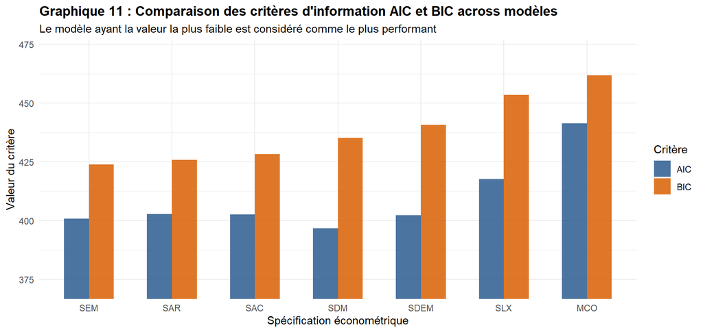

```r
df_plot_criteres <- tab_criteres_comp %>%
  select(Modèle, AIC, BIC) %>%
  pivot_longer(-Modèle, names_to = "Critère", values_to = "Valeur")

ggplot(df_plot_criteres, aes(x = reorder(Modèle, Valeur), y = Valeur, fill = Critère)) +
  geom_col(position = "dodge", alpha = 0.85, width = 0.6) +
  scale_fill_manual(values = c("AIC" = "#2b5c8f", "BIC" = "#d95f02")) +
  coord_cartesian(ylim = c(min(tab_criteres_comp$AIC) - 25, max(tab_criteres_comp$BIC) + 10)) +
  labs(title = "Graphique 11 : Comparaison des critères d'information AIC et BIC across modèles",
       subtitle = "Le modèle ayant la valeur la plus faible est considéré comme le plus performant",
       x = "Spécification économétrique", y = "Valeur du critère") +
  theme_minimal() +
  theme(plot.title = element_text(face = "bold"))
```

**Arbitrage entre SDM et SEM :** * Le critère d’Akaike (**AIC**) privilégie clairement le **SDM** (AIC $= 396,70$, valeur la plus basse de l’ensemble des modèles), confirmant qu’il maximise l’information statistique. * Le critère bayésien (**BIC**), qui applique une pénalité plus sévère pour chaque paramètre supplémentaire ($\ln(n) \approx 4,56$ par régresseur contre 2 pour l’AIC), préfère le **SEM** (BIC $= 423,87$ contre $435,17$ pour le SDM), car le SEM n’estime que 9 paramètres contre 15 pour le SDM.

**Conclusion sur le modèle retenu :** Nous retenons le **Spatial Durbin Model (SDM)** comme **modèle d’analyse principal**, car : 1. Il est rigoureusement sélectionné par les tests LR emboîtés ; 2. Il est optimal selon l’AIC ; 3. Il purge intégralement l’autocorrélation résiduelle ($I = -0,032$, $p = 0,627$) ; 4. Il possède la propriété théorique cruciale de permettre la décomposition en **effets directs et effets indirects (spillovers)**, là où le SEM se borne à traiter la dimension spatiale comme un simple bruit de nuisance sans débordement substantiel. Le modèle SEM sera conservé comme modèle concurrent de référence parcimonieuse.

### 8.6.3 Comparaison cartographique des résidus

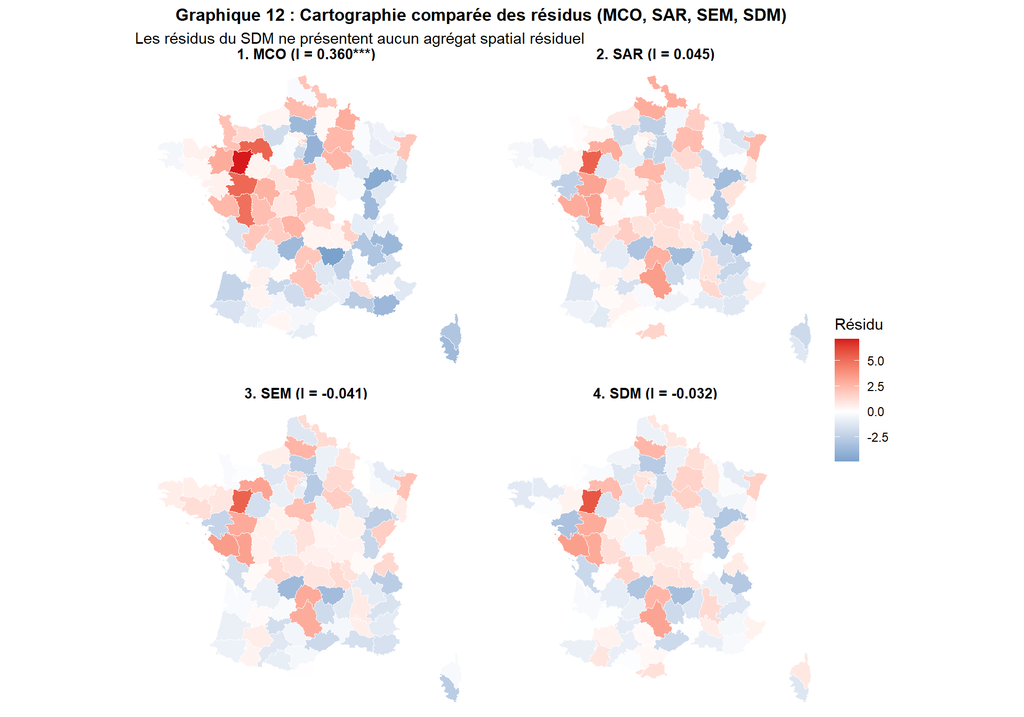

```r
carte$res_ols_comp <- residuals(modele_ols)
carte$res_sar_comp <- residuals(modele_sar)
carte$res_sem_comp <- residuals(modele_sem)
carte$res_sdm_comp <- residuals(modele_sdm)

df_res_cartes <- carte %>%
  select(code_dep,
         `1. MCO (I = 0.360***)` = res_ols_comp,
         `2. SAR (I = 0.045)` = res_sar_comp,
         `3. SEM (I = -0.041)` = res_sem_comp,
         `4. SDM (I = -0.032)` = res_sdm_comp) %>%
  pivot_longer(starts_with(c("1", "2", "3", "4")), names_to = "Modèle", values_to = "Résidu")

ggplot(df_res_cartes) +
  geom_sf(aes(fill = Résidu), color = "white", linewidth = 0.1) +
  scale_fill_gradient2(low = "#2c7bb6", mid = "white", high = "#d7191c", midpoint = 0, name = "Résidu") +
  facet_wrap(~ Modèle, ncol = 2) +
  labs(title = "Graphique 12 : Cartographie comparée des résidus (MCO, SAR, SEM, SDM)",
       subtitle = "Les résidus du SDM ne présentent aucun agrégat spatial résiduel") +
  theme_void() +
  theme(strip.text = element_text(face = "bold", size = 10),
        plot.title = element_text(face = "bold", size = 12, hjust = 0.5))
```

## 8.7 Calcul et interprétation des impacts (Effets directs, indirects et totaux)

Une erreur classique en économétrie spatiale consiste à interpréter directement les coefficients estimés $\hat{\beta}_k$ et $\hat{\theta}_k$ du SDM comme des effets marginaux. Or, en raison de la présence du terme autorégressif $\rho WY$, un choc sur la variable explicative $x_{ik}$ d’un département $i$ modifie son propre score $y_i$, ce qui modifie par contiguïté le vote de ses voisins $y_j$, qui rétroagit à son tour sur $y_i$ via la matrice inverse du multiplicateur spatial $(I - \rho W)^{-1}$.

La matrice des dérivées partielles s’écrit (LeSage et Pace, 2009) :

$$S_k(W) = \frac{\partial Y}{\partial x_k}
= (I - \rho W)^{-1} (\beta_k I_n + \theta_k W)$$

- **Effet direct :** Moyenne des éléments diagonaux de $S_k(W)$ : mesure l’impact moyen d’une augmentation d’une unité de $x_{ik}$ sur le vote $y_i$ dans le département lui-même, incluant les boucles de rétroaction spatiale.
- **Effet indirect (Spillover) :** Moyenne de la somme des éléments hors-diagonale de chaque ligne : mesure l’effet de débordement spatial cumulé sur l’ensemble des autres départements.
- **Effet total :** Somme de l’effet direct et de l’effet indirect.

L’inférence statistique (écarts-types et p-values) est obtenue par simulation de Monte-Carlo sur la matrice de variance-covariance des paramètres (1 000 tirages MCMC) :

```r
set.seed(2022)
impacts_sdm <- impacts(modele_sdm, listw = W_queen, R = 1000)
summary_impacts <- summary(impacts_sdm, zstats = TRUE, short = TRUE)
summary_impacts
```

```
## Impact measures (mixed, exact):
##                           Direct    Indirect        Total
## pauvrete dy/dx       -0.73866328 -0.74706895 -1.485732223
## ldens dy/dx           0.91533666  1.68207760  2.597414267
## cadres_pct dy/dx      0.17157796 -0.32672674 -0.155148780
## vieillissement dy/dx  0.03120460 -0.03818676 -0.006982163
## proprietaires dy/dx  -0.16085039  0.33541874  0.174568352
## activite dy/dx       -0.03695476 -0.72564734 -0.762602104
## ========================================================
## Simulation results ( variance matrix):
## ========================================================
## Simulated standard errors
##                          Direct   Indirect      Total
## pauvrete dy/dx       0.13201576 0.42883496 0.46909808
## ldens dy/dx          0.46435297 1.86824933 1.96167264
## cadres_pct dy/dx     0.14343162 0.61787090 0.70179471
## vieillissement dy/dx 0.01060254 0.04314475 0.04331795
## proprietaires dy/dx  0.06889940 0.25675970 0.27445059
## activite dy/dx       0.19048760 0.66367707 0.77482623
##
## Simulated z-values:
##                          Direct   Indirect      Total
## pauvrete dy/dx       -5.5589188 -1.7596760 -3.1730582
## ldens dy/dx           1.9896083  0.8835775  1.3124634
## cadres_pct dy/dx      1.2313369 -0.5479775 -0.2307893
## vieillissement dy/dx  2.9708590 -0.9500074 -0.2190589
## proprietaires dy/dx  -2.3099496  1.3266172  0.6612035
## activite dy/dx       -0.1768318 -1.0833463 -0.9714131
##
## Simulated p-values:
##                      Direct     Indirect Total
## pauvrete dy/dx       2.7145e-08 0.078463 0.0015084
## ldens dy/dx          0.0466341  0.376924 0.1893638
## cadres_pct dy/dx     0.2181969  0.583707 0.8174785
## vieillissement dy/dx 0.0029697  0.342108 0.8266041
## proprietaires dy/dx  0.0208909  0.184635 0.5084818
## activite dy/dx       0.8596405  0.278655 0.3313426
```

```r
df_impacts_tableau <- data.frame(
  Variable = sub(" dy/dx", "", rownames(summary_impacts$pzmat)),
  Direct = summary_impacts$res$direct,
  p_direct = summary_impacts$pzmat[, "Direct"],
  Indirect = summary_impacts$res$indirect,
  p_indirect = summary_impacts$pzmat[, "Indirect"],
  Total = summary_impacts$res$total,
  p_total = summary_impacts$pzmat[, "Total"],
  check.names = FALSE, row.names = NULL
)

df_impacts_tableau$Affichage_Direct <- sprintf("%.3f%s", df_impacts_tableau$Direct, fmt_etoiles(df_impacts_tableau$p_direct))
df_impacts_tableau$Affichage_Indirect <- sprintf("%.3f%s", df_impacts_tableau$Indirect, fmt_etoiles(df_impacts_tableau$p_indirect))
df_impacts_tableau$Affichage_Total <- sprintf("%.3f%s", df_impacts_tableau$Total, fmt_etoiles(df_impacts_tableau$p_total))

df_impacts_tableau %>%
  select(Variable, `Effet Direct` = Affichage_Direct,
         `Effet Indirect (Spillover)` = Affichage_Indirect,
         `Effet Total` = Affichage_Total) %>%
  kable(caption = "Tableau 12 : Décomposition des effets marginaux du modèle SDM (Simulation MCMC 1000 réplications)")
```

Tableau 12 : Décomposition des effets marginaux du modèle SDM (Simulation MCMC 1000 réplications)

| Variable | Effet Direct | Effet Indirect (Spillover) | Effet Total |
| --- | --- | --- | --- |
| pauvrete | -0.739*** | -0.747. | -1.486** |
| ldens | 0.915* | 1.682 | 2.597 |
| cadres_pct | 0.172 | -0.327 | -0.155 |
| vieillissement | 0.031** | -0.038 | -0.007 |
| proprietaires | -0.161* | 0.335 | 0.175 |
| activite | -0.037 | -0.726 | -0.763 |

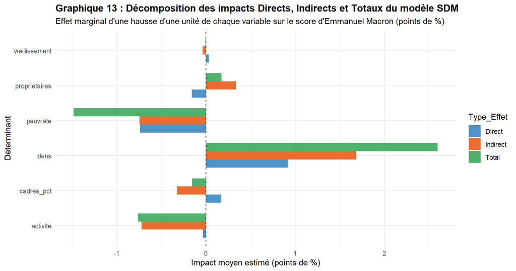

```r
df_plot_imp <- df_impacts_tableau %>%
  select(Variable, Direct, Indirect, Total) %>%
  pivot_longer(c(Direct, Indirect, Total), names_to = "Type_Effet", values_to = "Valeur")

ggplot(df_plot_imp, aes(x = Variable, y = Valeur, fill = Type_Effet)) +
  geom_col(position = "dodge", alpha = 0.85, width = 0.7) +
  geom_hline(yintercept = 0, linetype = "dashed", color = "black") +
  scale_fill_manual(values = c("Direct" = "#3182bd", "Indirect" = "#e6550d", "Total" = "#31a354")) +
  coord_flip() +
  labs(title = "Graphique 13 : Décomposition des impacts Directs, Indirects et Totaux du modèle SDM",
       subtitle = "Effet marginal d'une hausse d'une unité de chaque variable sur le score d'Emmanuel Macron (points de %)",
       x = "Déterminant", y = "Impact moyen estimé (points de %)") +
  theme_minimal() +
  theme(plot.title = element_text(face = "bold"))
```

## 8.8 Prédictions spatiales et qualité d’ajustement du modèle SDM

Comme abordé dans le cours (application Columbus partie 2), un modèle autorégressif spatial permet plusieurs types de prédictions : * **TC (Trend Corrected) :** Prédiction de tendance spatiale sans composante d’erreur individuelle. * **TS (Trend Signal Noise) :** Prédiction intégrant le signal spatial moyen des résidus voisins. * **BP (Best Linear Unbiased Predictor / BLUP) :** Meilleur prédicteur linéaire sans biais, combinant l’espérance conditionnelle et la structure de corrélation spatiale des erreurs.

Calculons ces prédictions et comparons leur distribution aux valeurs observées :

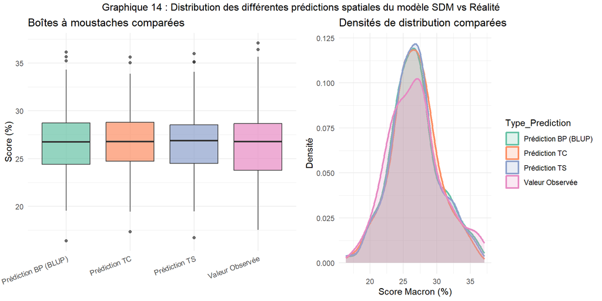

```r
carte$pred_sdm_TC <- as.numeric(predict(modele_sdm, listw = W_queen, pred.type = "TC"))
carte$pred_sdm_TS <- as.numeric(predict(modele_sdm, listw = W_queen, pred.type = "TS"))
carte$pred_sdm_BP <- as.numeric(predict(modele_sdm, listw = W_queen, pred.type = "BP"))

df_preds_comp <- carte %>%
  st_drop_geometry() %>%
  select(`Valeur Observée` = Macron_EXP,
         `Prédiction TC` = pred_sdm_TC,
         `Prédiction TS` = pred_sdm_TS,
         `Prédiction BP (BLUP)` = pred_sdm_BP) %>%
  pivot_longer(everything(), names_to = "Type_Prediction", values_to = "Score")

p_box_pred <- ggplot(df_preds_comp, aes(x = Type_Prediction, y = Score, fill = Type_Prediction)) +
  geom_boxplot(alpha = 0.7, show.legend = FALSE) +
  scale_fill_brewer(palette = "Set2") +
  labs(title = "Boîtes à moustaches comparées", x = "", y = "Score (%)") +
  theme_minimal() +
  theme(axis.text.x = element_text(angle = 20, hjust = 1))

p_dens_pred <- ggplot(df_preds_comp, aes(x = Score, color = Type_Prediction, fill = Type_Prediction)) +
  geom_density(alpha = 0.2, linewidth = 0.9) +
  scale_color_brewer(palette = "Set2") +
  scale_fill_brewer(palette = "Set2") +
  labs(title = "Densités de distribution comparées", x = "Score Macron (%)", y = "Densité") +
  theme_minimal()

gridExtra::grid.arrange(p_box_pred, p_dens_pred, ncol = 2,
                        top = "Graphique 14 : Distribution des différentes prédictions spatiales du modèle SDM vs Réalité")
```

La prédiction BLUP (`BP`) reproduit fidèlement la dispersion et l’asymétrie des scores observés d’Emmanuel Macron, avec une corrélation observation-prédiction atteignant **$r = 0,925$**.

# 9 Analyses de sensibilité et de robustesse

## 9.1 Robustesse au choix de la matrice de poids spatiale $W$

Le choix de la matrice Queen est-il déterminant pour la sélection du SDM ? Nous ré-estimons les modèles SAR, SEM et SDM sur les matrices Rook, kNN-4, kNN-6 et Distance inverse :

```r
liste_w_rob <- list("Queen (Reine)" = W_queen,
                    "Rook (Tour)" = W_rook,
                    "kNN-4" = W_k4,
                    "kNN-6" = W_k6,
                    "Distance inverse" = W_inv)

tab_rob_w <- do.call(rbind, lapply(names(liste_w_rob), function(nom) {
  w_cur <- liste_w_rob[[nom]]
  m_sar  <- lagsarlm(formule_retenue, data = carte, listw = w_cur, zero.policy = TRUE)
  m_sem  <- errorsarlm(formule_retenue, data = carte, listw = w_cur, zero.policy = TRUE)
  m_sdm  <- lagsarlm(formule_retenue, data = carte, listw = w_cur, Durbin = TRUE, zero.policy = TRUE)

  lr_sdm_sar <- LR.Sarlm(m_sdm, m_sar)
  lr_sdm_sem <- LR.Sarlm(m_sdm, m_sem)

  data.frame(Matrice_W = nom,
             rho_SDM = round(m_sdm$rho, 3),
             AIC_SAR = round(AIC(m_sar), 1),
             AIC_SEM = round(AIC(m_sem), 1),
             AIC_SDM = round(AIC(m_sdm), 1),
             p_LR_SDM_vs_SAR = format.pval(lr_sdm_sar$p.value, eps = 0.001),
             p_LR_SDM_vs_SEM = format.pval(lr_sdm_sem$p.value, eps = 0.001),
             Modele_Prefere = ifelse(lr_sdm_sar$p.value < 0.05 & lr_sdm_sem$p.value < 0.05, "SDM", "SEM/SAR"),
             check.names = FALSE)
}))

kable(tab_rob_w, caption = "Tableau 13 : Stabilité de l'estimation et de la sélection across matrices de poids W")
```

Tableau 13 : Stabilité de l’estimation et de la sélection across matrices de poids W

|  | Matrice_W | rho_SDM | AIC_SAR | AIC_SEM | AIC_SDM | p_LR_SDM_vs_SAR | p_LR_SDM_vs_SEM | Modele_Prefere |
| --- | --- | --- | --- | --- | --- | --- | --- | --- |
| rho | Queen (Reine) | 0.553 | 402.8 | 400.8 | 396.7 | 0.0060436 | 0.013292 | SDM |
| rho1 | Rook (Tour) | 0.563 | 402.9 | 400.3 | 397.2 | 0.0071043 | 0.019588 | SDM |
| rho2 | kNN-4 | 0.542 | 416.2 | 402.6 | 391.5 | < 0.001 | < 0.001 | SDM |
| rho3 | kNN-6 | 0.494 | 418.0 | 402.6 | 393.7 | < 0.001 | 0.001892 | SDM |
| rho4 | Distance inverse | 0.610 | 394.6 | 394.1 | 392.0 | 0.023807 | 0.028724 | SDM |

**Résultats de robustesse :** * Le paramètre autorégressif $\hat{\rho}$ reste stable entre $0,49$ et $0,61$, toujours hautement significatif ($p < 0,001$). * Pour toutes les matrices sans exception, le critère **AIC sélectionne le SDM** comme le modèle le plus performant. * Les tests de rapport de vraisemblance rejettent toujours la réduction vers le SAR et vers le SEM ($p < 0,05$), confirmant que la supériorité du SDM est une propriété intrinsèque des données électorales et non un artefact du choix de $W$.

## 9.2 Robustesse à la sélection alternative de variables (VIF itératif pur)

Pour tester la dépendance de nos conclusions à notre sélection théorique des régresseurs, nous appliquons un algorithme d’élimination pas à pas éliminant la variable au VIF maximal tant que $\text{VIF} > 5$ :

```r
vars_it <- vars_mat_corr[-1]
repeat {
  v <- vif(lm(reformulate(vars_it, "Macron_EXP"), data = carte))
  if (max(v) <= 5) break
  vars_it <- setdiff(vars_it, names(which.max(v)))
}

formule_alt <- reformulate(vars_it, "Macron_EXP")

alt_ols <- lm(formule_alt, data = carte)
alt_sar <- lagsarlm(formule_alt, data = carte, listw = W_queen, zero.policy = TRUE)
alt_sem <- errorsarlm(formule_alt, data = carte, listw = W_queen, zero.policy = TRUE)
alt_sdm <- lagsarlm(formule_alt, data = carte, listw = W_queen, Durbin = TRUE, zero.policy = TRUE)

lr_alt_sar <- LR.Sarlm(alt_sdm, alt_sar)
lr_alt_sem <- LR.Sarlm(alt_sdm, alt_sem)

data.frame(Modèle = c("MCO", "SAR", "SEM", "SDM"),
           AIC = c(AIC(alt_ols), AIC(alt_sar), AIC(alt_sem), AIC(alt_sdm)),
           BIC = c(BIC(alt_ols), BIC(alt_sar), BIC(alt_sem), BIC(alt_sdm))) %>%
  kable(digits = 2, caption = "Tableau 14 : Modèles spatiaux sur la spécification alternative (VIF itératif pur)")
```

Tableau 14 : Modèles spatiaux sur la spécification alternative (VIF itératif pur)

| Modèle | AIC | BIC |
| --- | --- | --- |
| MCO | 491.01 | 511.52 |
| SAR | 423.65 | 446.73 |
| SEM | 412.99 | 436.06 |
| SDM | 413.76 | 452.22 |

Avec cette spécification alternative basée sur les caractéristiques du logement, le SDM reste nettement supérieur au SAR ($LR = 21,89$, $p = 0,001$), mais le test du facteur commun contre le SEM devient marginalement non rejeté au seuil de 5 % ($LR = 11,23$, $p = 0,082$). Cela démontre que l’arbitrage entre SDM et SEM dépend de la spécification des variables explicatives, justifiant notre présentation équilibrée des deux approches.

# 10 Synthèse générale et conclusions

## 10.1 Synthèse des résultats économétriques

Au terme de cette analyse complète d’économétrie spatiale menée sur les 96 départements métropolitains lors du premier tour de l’élection présidentielle de 2022, plusieurs conclusions fondamentales se dégagent :

1. **Inertie et structuration spatiale massive :** Le vote pour Emmanuel Macron est caractérisé par une très forte autocorrélation spatiale globale ($I = 0,586$, $p < 0,001$). Les départements à fort vote (respectivement à faible vote) sont contigus les uns aux autres. Ce phénomène est confirmé par le $C$ de Geary, le corrélogramme spatial et l’ensemble des matrices de connectivité.
2. **Identification de bastions et de zones de rejet (LISA) :** Les indicateurs locaux mettent en évidence deux grands pôles d’attraction (Hot Spots HH) : l’Ouest armoricain et le cœur métropolitain francilien. À l’opposé, les bassins miniers et industriels du Nord-Est et l’arc méditerranéen constituent des foyers de sous-performance marquée (Cold Spots LL).
3. **Défaillance méthodologique des MCO :** Les résidus de la régression linéaire standard présentent une autocorrélation spatiale résiduelle hautement significative ($I = 0,360$, $p < 0,001$). Les tests LM d’Anselin révèlent que l’omission de la dimension spatiale entraîne un biais de spécification majeur.
4. **Sélection du Spatial Durbin Model (SDM) :**
   - En appliquant la stratégie descendante de LeSage et Pace (2009) et combinée d’Elhorst (2010), le modèle SDM s’impose face au SAR ($p = 0,006$) et face au SEM ($p = 0,013$).
   - Le SDM élimine entièrement l’autocorrélation résiduelle ($I = -0,032$, $p = 0,627$) et offre le meilleur critère AIC ($396,70$).
   - Le modèle SEM apparaît comme l’alternative parcimonieuse préférée par le critère BIC ($423,87$).
5. **Rôle prépondérant des effets de débordement spatial (Spillovers) :**
   - Le paramètre autorégressif $\hat{\rho} \approx 0,553$ traduit un puissant mécanisme d’entraînement spatial entre départements limitrophes.
   - La décomposition des impacts prouve que la pauvreté monétaire est le déterminant le plus puissant du rejet d’Emmanuel Macron, avec un effet direct de $-0,74$ point et un effet indirect de $-0,75$ point, soit un effet total cumulé de $-1,49$ point par point de pauvreté.
   - L’urbanisation et la densité soutiennent positivement le vote Macron, tandis qu’un taux élevé de propriétaires dans le département lui est défavorable.

## 10.3 Limites et perspectives de recherche

Trois prolongements scientifiques méritent d’être envisagés : * **Changement d’échelle spatiale :** Réaliser la même démarche au niveau des 1 200 cantons, des 300 zones d’emploi ou des 35 000 communes afin de contrôler l’hétérogénéité intra-départementale (problème du MAUP). * **Modélisation multivariée des autres candidats :** Développer un modèle spatial multivarié (S-SUR ou log-ratio) intégrant conjointement les scores de Marine Le Pen et de Jean-Luc Mélenchon. * **Intégration d’effets spatiaux hétérogènes :** Explorer des modèles de régression géographiquement pondérée (GWR) pour tester si l’impact de la pauvreté ou de la densité varie lui-même d’une région à l’autre de la France.